# Mucosal microbiota alterations in primary sclerosis cholangitis persist after liver transplantation and are associated with clinical features independently of geography

##### 2.4.2.2.1 pre_ltx vs healthy

```r
group <- c("healthy","pre_ltx")
comparison_name <- paste0(group[1], " vs ",group[2])
```

**linDA**

```r
# prepare the data
linda_data <- binomial_prep(ileum_phylum_tab,
                            ileum_phylum_taxa_tab,
                            ileum_metadata,
                            group, usage="linDA")
```

```
Removing 2 ASV(s)
```

```r
filt_ileum_uni_data <- linda_data[[1]]
filt_ileum_uni_taxa <- linda_data[[2]]
filt_ileum_uni_metadata <- linda_data[[3]]

# fit the model
linda.obj <- linda(filt_ileum_uni_data,
                   filt_ileum_uni_metadata,
                   formula = '~ Group * Country')
```

```
0  features are filtered!
The filtered data has  143  samples and  10  features will be tested!
Imputation approach is used.
Fit linear models ...
Completed.
```

```r
linda.output <- linda.obj$output
linda.output <- linda_renaming(linda.output, group)

# save the results
group1 <- paste0(group[1], " vs ","Group",group[2])
group2 <- paste0(group[1], " , ",group[2], " - CZ vs NO")
group3 <- paste0(group[1], " vs ","Group",group[2], ":CountryNO")

for (grp in c(group1,group2,group3)){
  raw_linda_results_phylum[[segment]][[grp]] <-
    rawlinda.df(linda.output,
                grp,
                filt_ileum_uni_data,
                filt_ileum_uni_taxa)

  linda_results_phylum[[segment]][[grp]] <-
    linda.df(linda.output,
             grp,
             filt_ileum_uni_data,
             filt_ileum_uni_taxa)
}
```

```r
# volcano plot
volcano_1 <- volcano_plot_linda(linda.output,
                                group1,
                                taxa_table = filt_ileum_uni_taxa) +
            ggtitle(comparison_title)
```

```
Using Phylum for naming
```

```r
volcano_2  <- volcano_plot_linda(linda.output, group2,
                                taxa_table = filt_ileum_uni_taxa) +
            ggtitle("NO vs CZ")
```

```
Using Phylum for naming
```

```r
volcano_3 <- volcano_plot_linda(linda.output, group3,
                                taxa_table = filt_ileum_uni_taxa) +
            ggtitle("Interaction effect")
```

```
Using Phylum for naming
```

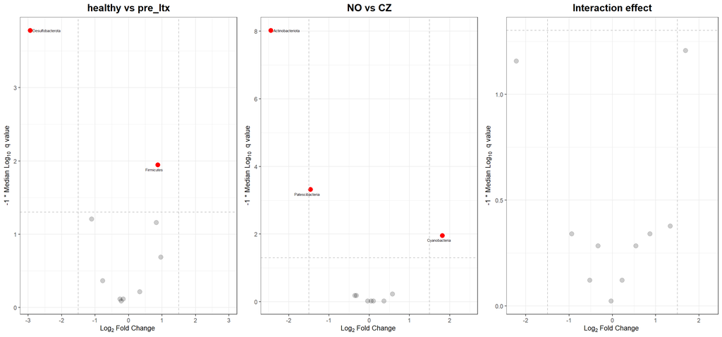

```r
volcano <- ggarrange(volcano_1,volcano_2,volcano_3, ncol=3)
volcano
```

**MaAsLin2**

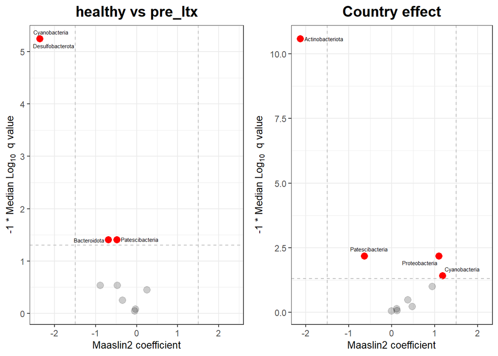

```r
volcano1 <- volcano_plot_maaslin(fit_data,filt_ileum_uni_taxa) +
            ggtitle(comparison_title)

volcano2 <- volcano_plot_maaslin(fit_data,filt_ileum_uni_taxa,variable="Country") +
            ggtitle("Country effect")

volcano <- ggarrange(volcano1,volcano2, ncol=2)
volcano
```

**Group - Intersection**

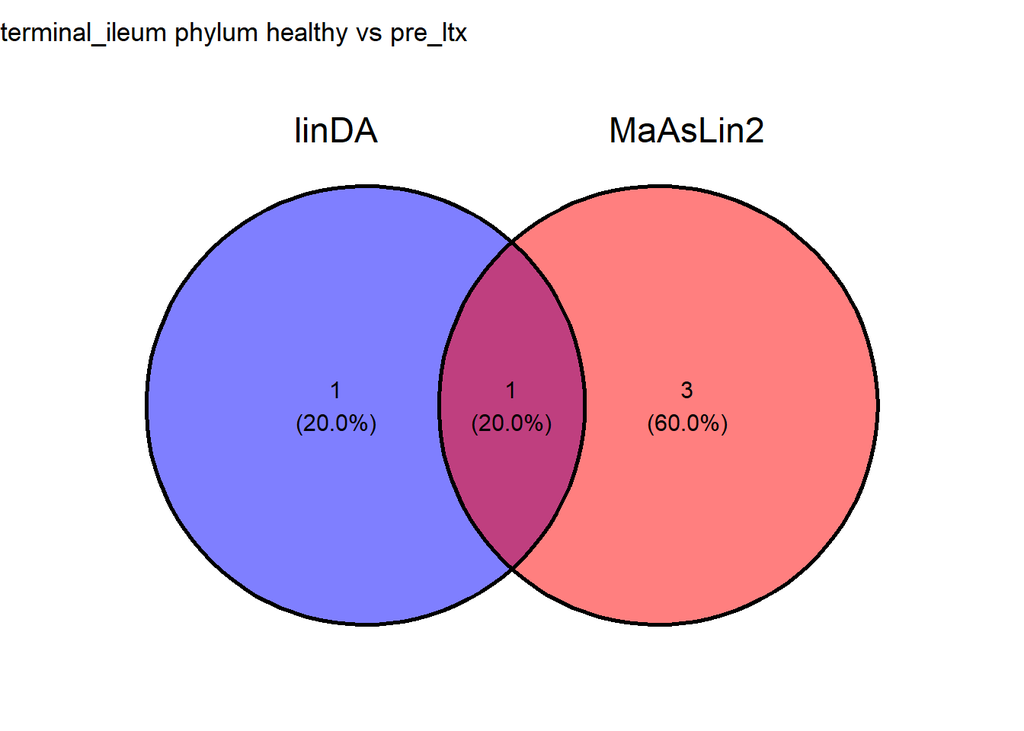

```r
intersection_results <- group_intersection(group, list_intersections, list_venns,
                                           linda.output, fit_data,
                                           raw_linda_results_phylum,
                                           segment = segment,
                                           level=level)

list_intersections <- intersection_results[[1]]
list_venns <- intersection_results[[2]]
venn <- intersection_results[[3]]

# show the results
venn
```

**Interaction effect**

```r
list_interaction_significant <- country_interaction(group,
                                                    linda.output,
                                                    list_intersections,
                                          filt_ileum_uni_data,
                                          filt_ileum_uni_metadata,
                                          segment=segment,
                                          level=level)

# see the result
## significant interaction effect
list_interaction_significant[[1]]
```

```r
## results for czech cohort
list_interaction_significant[[2]]
```

```
[1] NA
```

```r
## results for norwegian cohort
list_interaction_significant[[3]]
```

```
[1] NA
```

**Removing problematic taxa**

```r
list_intersections <- removing_interaction_problems(group,
                                                    list_interaction_significant,
                                                    list_intersections,
                                                    segment=segment,
                                                    level=level)
```

**Basic statistics**

```r
uni_df <-  merge(basic_univariate_statistics(linda_data,group),
                 raw_linda_results_phylum[[segment]][[group1]],
                 by="SeqID",all=TRUE)
```

```
[1] "healthy"
[1] "pre_ltx"
[1] "healthy"
[1] "pre_ltx"
```

```r
uni_df[["final_sig"]] <- uni_df$SeqID %in% list_intersections[[paste(segment,level,comparison_name)]][["SeqID"]]
uni_statistics[[segment]][[paste(level,comparison_name)]] <- uni_df

# for comparison
new_name <- paste(level,comparison_name)
addWorksheet(supplements_wb, sheetName = new_name)
writeData(supplements_wb, sheet = new_name, uni_df, rowNames=FALSE)
```

##### 2.4.2.2.2 pre_ltx vs post_ltx

```r
group <- c("pre_ltx","post_ltx")
comparison_name <- paste0(group[1], " vs ",group[2])
```

**linDA**

```r
# prepare the data
linda_data <- binomial_prep(ileum_phylum_tab,
                            ileum_phylum_taxa_tab,
                            ileum_metadata,
                            group, usage="linDA")
```

```
Removing 2 ASV(s)
```

```r
filt_ileum_uni_data <- linda_data[[1]]
filt_ileum_uni_taxa <- linda_data[[2]]
filt_ileum_uni_metadata <- linda_data[[3]]

# fit the model
linda.obj <- linda(filt_ileum_uni_data,
                   filt_ileum_uni_metadata,
                   formula = '~ Group * Country')
```

```
0  features are filtered!
The filtered data has  208  samples and  10  features will be tested!
Imputation approach is used.
Fit linear models ...
Completed.
```

```r
linda.output <- linda.obj$output
linda.output <- linda_renaming(linda.output, group)

# save the results
group1 <- paste0(group[1], " vs ","Group",group[2])
group2 <- paste0(group[1], " , ",group[2], " - CZ vs NO")
group3 <- paste0(group[1], " vs ","Group",group[2], ":CountryNO")

for (grp in c(group1,group2,group3)){
  raw_linda_results_phylum[[segment]][[grp]] <-
    rawlinda.df(linda.output,
                grp,
                filt_ileum_uni_data,
                filt_ileum_uni_taxa)

  linda_results_phylum[[segment]][[grp]] <-
    linda.df(linda.output,
             grp,
             filt_ileum_uni_data,
             filt_ileum_uni_taxa)
}
```

```r
# volcano plot
volcano_1 <- volcano_plot_linda(linda.output,
                                group1,
                                taxa_table = filt_ileum_uni_taxa) +
            ggtitle(comparison_title)
```

```
Using Phylum for naming
```

```r
volcano_2  <- volcano_plot_linda(linda.output, group2,
                                taxa_table = filt_ileum_uni_taxa) +
            ggtitle("NO vs CZ")
```

```
Using Phylum for naming
```

```r
volcano_3 <- volcano_plot_linda(linda.output, group3,
                                taxa_table = filt_ileum_uni_taxa) +
            ggtitle("Interaction effect")
```

```
Using Phylum for naming
```

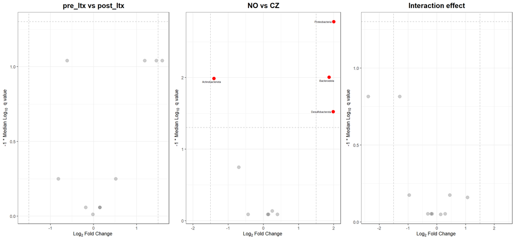

```r
volcano <- ggarrange(volcano_1,volcano_2,volcano_3, ncol=3)
volcano
```

**MaAsLin2**

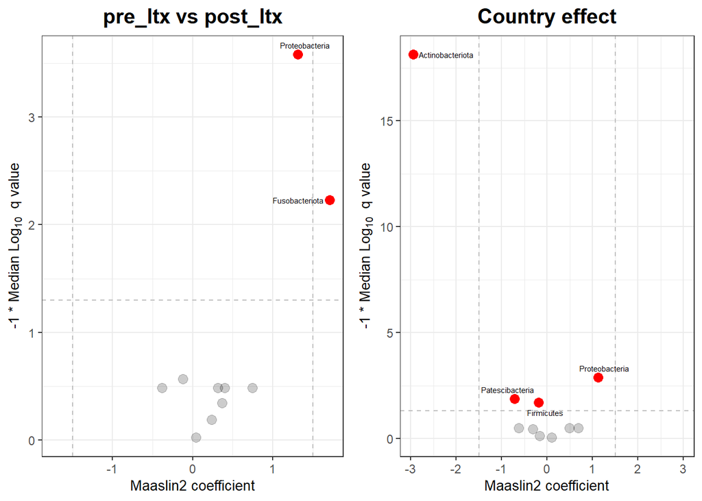

```r
volcano1 <- volcano_plot_maaslin(fit_data,filt_ileum_uni_taxa) +
            ggtitle(comparison_title)

volcano2 <- volcano_plot_maaslin(fit_data,filt_ileum_uni_taxa,variable="Country") +
            ggtitle("Country effect")

volcano <- ggarrange(volcano1,volcano2, ncol=2)
volcano
```

**Group - Intersection**

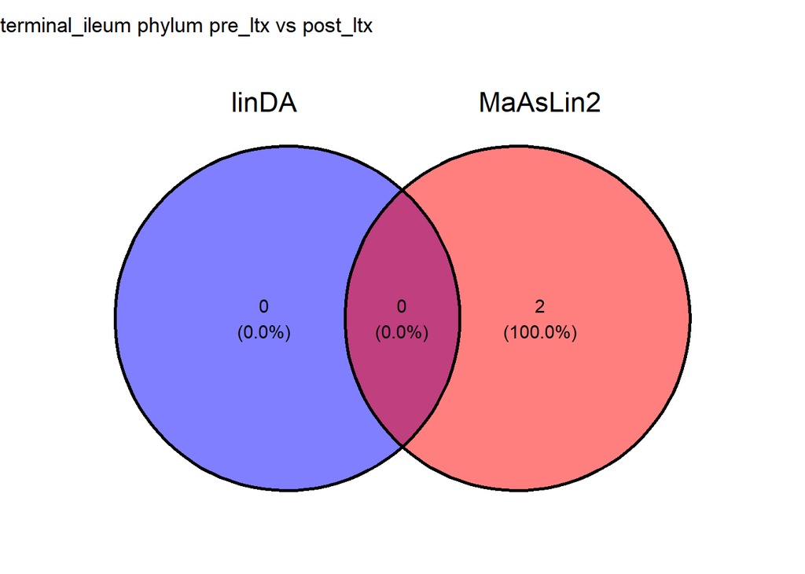

```r
intersection_results <- group_intersection(group, list_intersections, list_venns,
                                           linda.output, fit_data,
                                           raw_linda_results_phylum,
                                           segment = segment,
                                           level=level)

list_intersections <- intersection_results[[1]]
list_venns <- intersection_results[[2]]
venn <- intersection_results[[3]]

# show the results
venn
```

**Interaction effect**

```r
list_interaction_significant <- country_interaction(group,
                                                    linda.output,
                                                    list_intersections,
                                          filt_ileum_uni_data,
                                          filt_ileum_uni_metadata,
                                          segment=segment,
                                          level=level)

# see the result
## significant interaction effect
list_interaction_significant[[1]]
```

```r
## results for czech cohort
list_interaction_significant[[2]]
```

```
[1] NA
```

```r
## results for norwegian cohort
list_interaction_significant[[3]]
```

```
[1] NA
```

**Removing problematic taxa**

```r
list_intersections <- removing_interaction_problems(group,
                                                    list_interaction_significant,
                                                    list_intersections,
                                                    segment=segment,
                                                    level=level)
```

**Basic statistics**

```r
uni_df <-  merge(basic_univariate_statistics(linda_data,group),
                 raw_linda_results_phylum[[segment]][[group1]],
                 by="SeqID",all=TRUE)
```

```
[1] "pre_ltx"
[1] "post_ltx"
[1] "pre_ltx"
[1] "post_ltx"
```

```r
uni_df[["final_sig"]] <- uni_df$SeqID %in% list_intersections[[paste(segment,level,comparison_name)]][["SeqID"]]
uni_statistics[[segment]][[paste(level,comparison_name)]] <- uni_df

# for comparison
new_name <- paste(level,comparison_name)
addWorksheet(supplements_wb, sheetName = new_name)
writeData(supplements_wb, sheet = new_name, uni_df, rowNames=FALSE)
```

##### 2.4.2.2.3 post_ltx vs healthy

```r
group <- c("healthy","post_ltx")
comparison_name <- paste0(group[1], " vs ",group[2])
```

**linDA**

```r
# prepare the data
linda_data <- binomial_prep(ileum_phylum_tab,
                            ileum_phylum_taxa_tab,
                            ileum_metadata,
                            group, usage="linDA")
```

```
Removing 1 ASV(s)
```

```r
filt_ileum_uni_data <- linda_data[[1]]
filt_ileum_uni_taxa <- linda_data[[2]]
filt_ileum_uni_metadata <- linda_data[[3]]

# fit the model
linda.obj <- linda(filt_ileum_uni_data,
                   filt_ileum_uni_metadata,
                   formula = '~ Group * Country')
```

```
0  features are filtered!
The filtered data has  211  samples and  10  features will be tested!
Imputation approach is used.
Fit linear models ...
Completed.
```

```r
linda.output <- linda.obj$output
linda.output <- linda_renaming(linda.output, group)

# save the results
group1 <- paste0(group[1], " vs ","Group",group[2])
group2 <- paste0(group[1], " , ",group[2], " - CZ vs NO")
group3 <- paste0(group[1], " vs ","Group",group[2], ":CountryNO")

for (grp in c(group1,group2,group3)){
  raw_linda_results_phylum[[segment]][[grp]] <-
    rawlinda.df(linda.output,
                grp,
                filt_ileum_uni_data,
                filt_ileum_uni_taxa)

  linda_results_phylum[[segment]][[grp]] <-
    linda.df(linda.output,
             grp,
             filt_ileum_uni_data,
             filt_ileum_uni_taxa)
}
```

```r
# volcano plot
volcano_1 <- volcano_plot_linda(linda.output,
                                group1,
                                taxa_table = filt_ileum_uni_taxa) +
            ggtitle(comparison_title)
```

```
Using Phylum for naming
```

```r
volcano_2  <- volcano_plot_linda(linda.output, group2,
                                taxa_table = filt_ileum_uni_taxa) +
            ggtitle("NO vs CZ")
```

```
Using Phylum for naming
```

```r
volcano_3 <- volcano_plot_linda(linda.output, group3,
                                taxa_table = filt_ileum_uni_taxa) +
            ggtitle("Interaction effect")
```

```
Using Phylum for naming
```

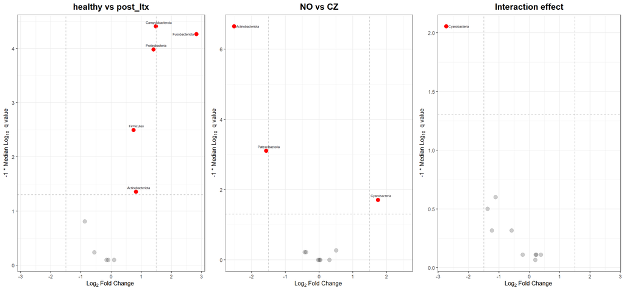

```r
volcano <- ggarrange(volcano_1,volcano_2,volcano_3, ncol=3)
volcano
```

**MaAsLin2**

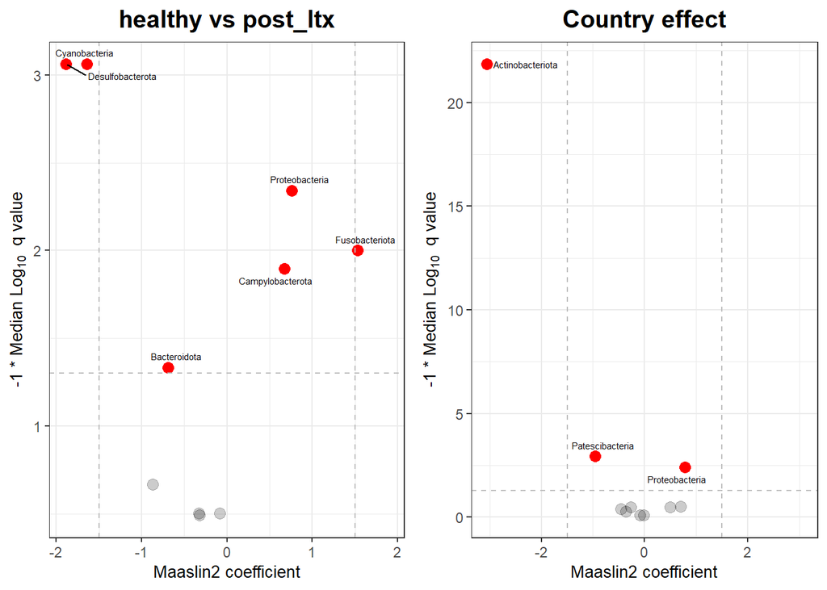

```r
volcano1 <- volcano_plot_maaslin(fit_data,filt_ileum_uni_taxa) +
            ggtitle(comparison_title)

volcano2 <- volcano_plot_maaslin(fit_data,filt_ileum_uni_taxa,variable="Country") +
            ggtitle("Country effect")

volcano <- ggarrange(volcano1,volcano2, ncol=2)
volcano
```

**Group - Intersection**

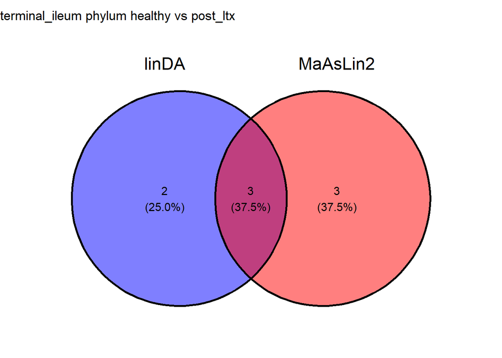

```r
intersection_results <- group_intersection(group, list_intersections, list_venns,
                                           linda.output, fit_data,
                                           raw_linda_results_phylum,
                                           segment = segment,
                                           level=level)

list_intersections <- intersection_results[[1]]
list_venns <- intersection_results[[2]]
venn <- intersection_results[[3]]

# show the results
venn
```

**Interaction effect**

```r
list_interaction_significant <- country_interaction(group,
                                                    linda.output,
                                                    list_intersections,
                                          filt_ileum_uni_data,
                                          filt_ileum_uni_metadata,
                                          segment=segment,
                                          level=level)

# see the result
## significant interaction effect
list_interaction_significant[[1]]
```

```r
## results for czech cohort
list_interaction_significant[[2]]
```

```
[1] NA
```

```r
## results for norwegian cohort
list_interaction_significant[[3]]
```

```
[1] NA
```

**Removing problematic taxa**

```r
list_intersections <- removing_interaction_problems(group,
                                                    list_interaction_significant,
                                                    list_intersections,
                                                    segment=segment,
                                                    level=level)
```

**Basic statistics**

```r
uni_df <-  merge(basic_univariate_statistics(linda_data,group),
                 raw_linda_results_phylum[[segment]][[group1]],
                 by="SeqID",all=TRUE)
```

```
[1] "healthy"
[1] "post_ltx"
[1] "healthy"
[1] "post_ltx"
```

```r
uni_df[["final_sig"]] <- uni_df$SeqID %in% list_intersections[[paste(segment,level,comparison_name)]][["SeqID"]]
uni_statistics[[segment]][[paste(level,comparison_name)]] <- uni_df

# for comparison
new_name <- paste(level,comparison_name)
addWorksheet(supplements_wb, sheetName = new_name)
writeData(supplements_wb, sheet = new_name, uni_df, rowNames=FALSE)
```

##### 2.4.2.2.4 Visualization

Heatmap visualizing the linDA’s logFoldChange for taxa with p < 0.1.

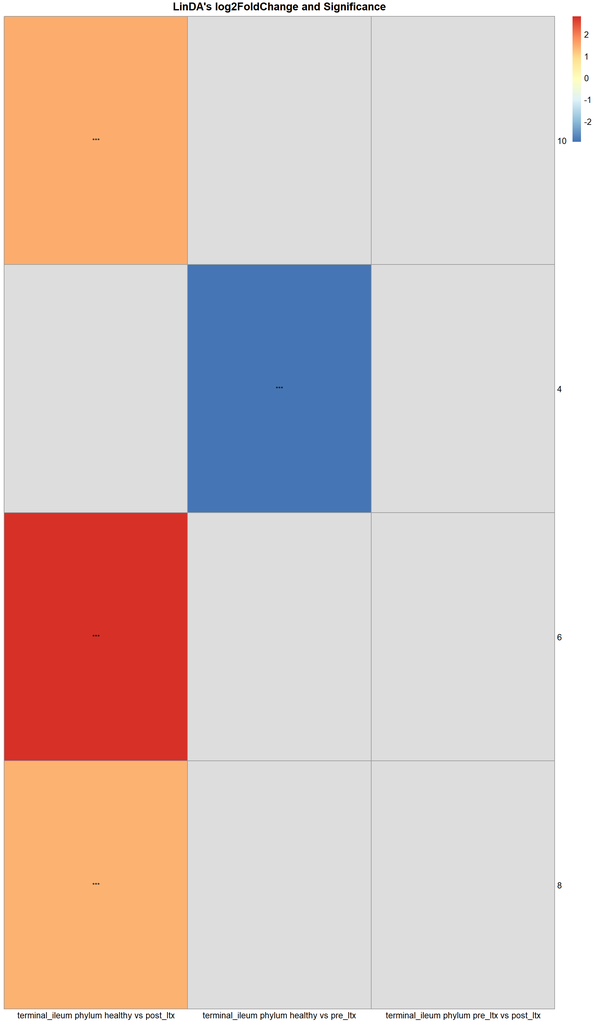

```r
list_heatmap <- list_intersections[grep(paste(segment,level),
                                  names(list_intersections),value=TRUE)]

p_heatmap_linda <- heatmap_linda(list_heatmap,ileum_taxa_tab)
p_heatmap_linda
```

**Dot heatmap**

```r
dotheatmap_linda <- dot_heatmap_linda(list_heatmap,
                                      uni_statistics$terminal_ileum[grepl(level,names(uni_statistics$terminal_ileum))],
                                      ileum_taxa_tab)
```

```
min_clr -4.119052
max_clr 3.1473
min_log -2.944293
max_log 2.82227
```

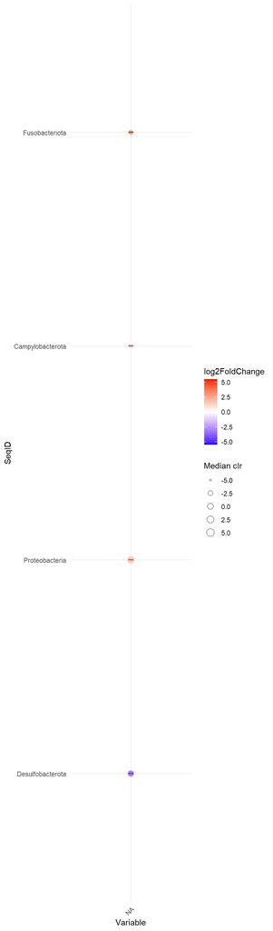

```r
dotheatmap_linda
```

##### 2.4.2.2.5 PSC effect

**pre_LTx vs Healthy and Post_LTx vs Healthy intersection**

```r
A <- list_intersections[[paste(segment,level,"healthy vs pre_ltx")]]$SeqID
B <- list_intersections[[paste(segment,level,"healthy vs post_ltx")]]$SeqID
C <- intersect(A,B)

psc_effect[[paste(segment,level)]] <- list_intersections[[paste(segment,level, "healthy vs pre_ltx")]][list_intersections[[paste(segment,level, "healthy vs pre_ltx")]]$SeqID %in% C,]

# see the results
psc_effect[[paste(segment,level)]]
```

```
[1] SeqID          Taxonomy       log2FoldChange p_value        padj
<0 rows> (or 0-length row.names)
```

#### 2.4.2.3 Saving results

```r
# ALL DATA
saveWorkbook(supplements_wb,file.path(path,paste0("supplements_uni_analysis_wb_",segment,".xlsx")),overwrite = TRUE)

# PSC effect
write.xlsx(psc_effect,
          file.path(path,paste0("supplements_psc_effect_",segment,".xlsx")))

# SIGNIFICANT taxa
write.xlsx(list_intersections[grepl(segment,names(list_intersections))] %>%
            `names<-`(gsub(segment, "", names(
              list_intersections[grepl(segment,names(list_intersections))]))),
           file.path(path,paste0("supplements_significant_taxa_",segment,".xlsx")))
```

## 2.5 Machine learning

Binary classification was performed using four independent models: Elastic Net (ENET), RF (RF), Gradient Boosting (GBoost), K-nearest Neighbors (kNN). Training and validation were performed via bootstrapping (N=500) on clr-transformed data. Model performance metrics expressed as AUC were calculated based on an out-of-sample principle.

The supplementary analysis contains training and validating at clr-transformed data at ASV level and relative-abundance data at ASV and genus level.

```r
path = "../results/Q1/models"
```

### 2.5.1 ENET

```r
model="enet"
```

#### 2.5.1.1 ASV level

```r
level="ASV"
```

##### 2.5.1.1.1 pre_ltx vs healthy

```r
group <- c("pre_ltx","healthy")
comparison_name <- paste0(group[1], " vs ",group[2])
```

```r
model_name <- paste(comparison_name,level,segment)

# prepare the data
filt_ileum_uni_data <- binomial_prep(ileum_asv_tab,
                                     ileum_taxa_tab,
                                     ileum_metadata,
                                     group, usage="ml_clr")
```

```
Removing 1598 ASV(s)
```

```
Removing 146 ASV(s)
```

```r
# fit the model
enet_model <- glmnet_binomial(filt_ileum_uni_data,
                              sample_method = "atypboot",
                              outcome="Group",
                              N=10,
                              reuse=TRUE,
                              file=model_name,
                              Q="Q1")

# ROC curve
roc_c <- roc_curve(enet_model, group)

# save the results
models_summ <- list()
models_cm <- list()
betas <- list()
roc_cs <- list()

models_summ[[model_name]] <- enet_model$model_summary
models_cm[[model_name]] <- enet_model$conf_matrices$original
roc_cs[[model_name]] <- enet_model$kfold_rocobjs
betas[[model_name]] <- as.matrix(enet_model$betas)

# see the results
enet_model$model_summary %>% t()
```

```
                                     [,1]
alpha                           0.4000000
lambda                          0.0256910
auc                             1.0000000
auc_czech                       1.0000000
auc_no                          1.0000000
auc_optimism_corrected          0.9562938
auc_optimism_corrected_CIL      0.8940903
auc_optimism_corrected_CIU      0.9955143
accuracy                        1.0000000
accuracy_czech                        NaN
accuracy_no                     1.0000000
accuracy_optimism_corrected     0.8824810
accuracy_optimism_corrected_CIL 0.7808636
accuracy_optimism_corrected_CIU 0.9600000
```

```r
enet_model$conf_matrices
```

```
$original
    Predicted
True  0  1
   0 73  0
   1  0 70

$czech
    Predicted
True  0  1
   0 37  0
   1  0 24

$no
    Predicted
True  0  1
   0 36  0
   1  0 46
```

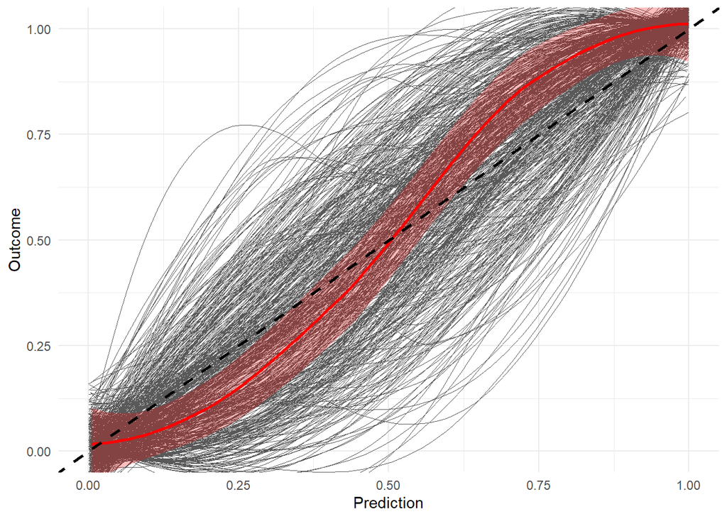

```r
enet_model$plot
```

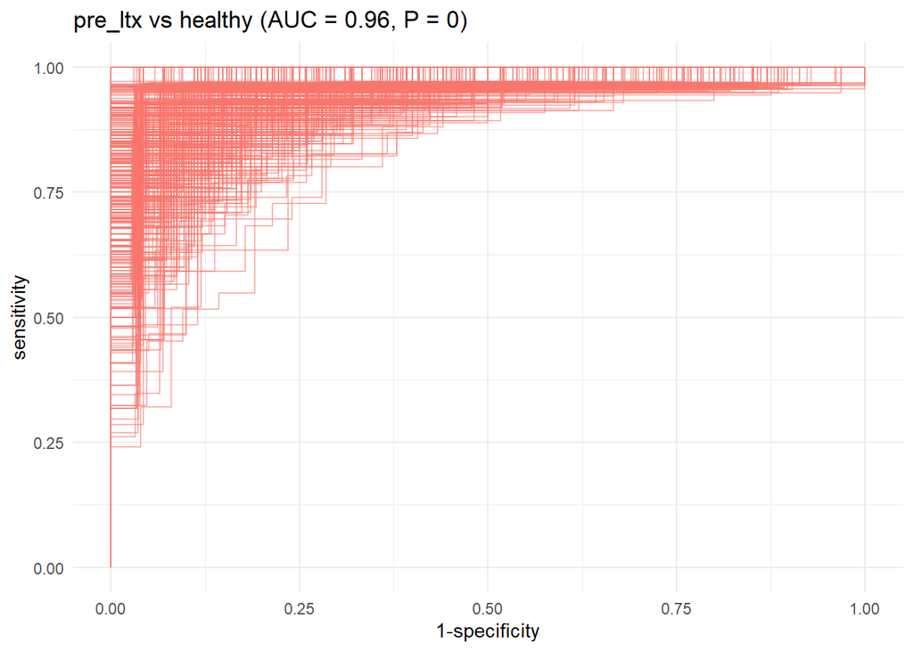

```r
roc_c
```

##### 2.5.1.1.2 pre_ltx vs post_ltx

```r
group <- c("pre_ltx","post_ltx")
comparison_name <- paste0(group[1], " vs ",group[2])
```

```r
model_name <- paste(comparison_name,level,segment)

# prepare the data
filt_ileum_uni_data <- binomial_prep(ileum_asv_tab,
                                     ileum_taxa_tab,
                                     ileum_metadata,
                                     group,
                                     usage="ml_clr")
```

```
Removing 979 ASV(s)
```

```
Removing 68 ASV(s)
```

```r
# fit the model
enet_model <- glmnet_binomial(filt_ileum_uni_data,
                              sample_method = "atypboot",
                              outcome="Group",
                              N=10,
                              reuse=TRUE,
                              file=model_name,
                              Q="Q1")

# ROC
roc_c <- roc_curve(enet_model, group)

# save the results
models_summ[[model_name]] <- enet_model$model_summary
models_cm[[model_name]] <- enet_model$conf_matrices$original
roc_cs[[model_name]] <- enet_model$kfold_rocobjs
betas[[model_name]] <- as.matrix(enet_model$betas)

# see the results
enet_model$model_summary %>% t()
```

```
                                     [,1]
alpha                           0.2000000
lambda                          0.1292328
auc                             0.9967909
auc_czech                       0.9979575
auc_no                          0.9969807
auc_optimism_corrected          0.8645187
auc_optimism_corrected_CIL      0.7852767
auc_optimism_corrected_CIU      0.9318161
accuracy                        0.9278846
accuracy_czech                        NaN
accuracy_no                     0.9512195
accuracy_optimism_corrected     0.8220597
accuracy_optimism_corrected_CIL 0.7333333
accuracy_optimism_corrected_CIU 0.8924940
```

```r
enet_model$conf_matrices
```

```
$original
    Predicted
True   0   1
   0 138   0
   1  15  55

$czech
    Predicted
True   0   1
   0 102   0
   1  11  13

$no
    Predicted
True  0  1
   0 36  0
   1  4 42
```

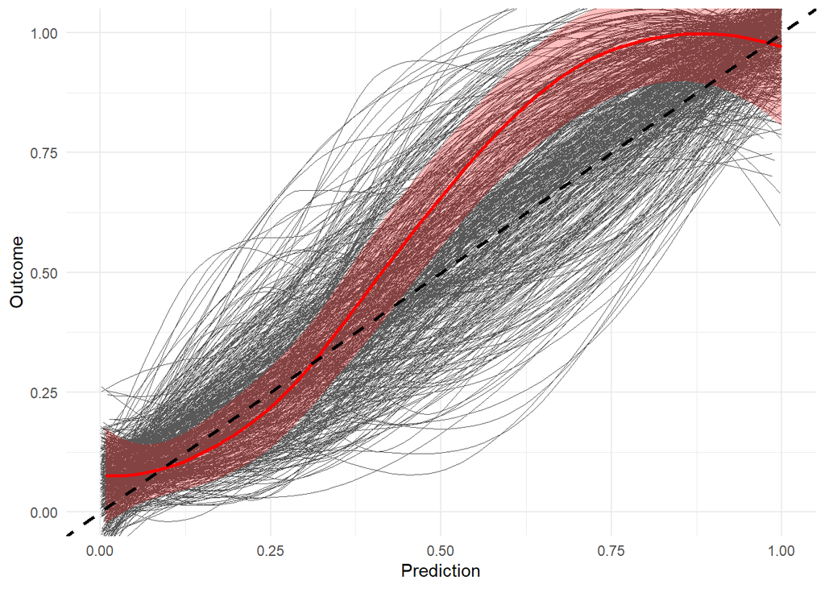

```r
enet_model$plot
```

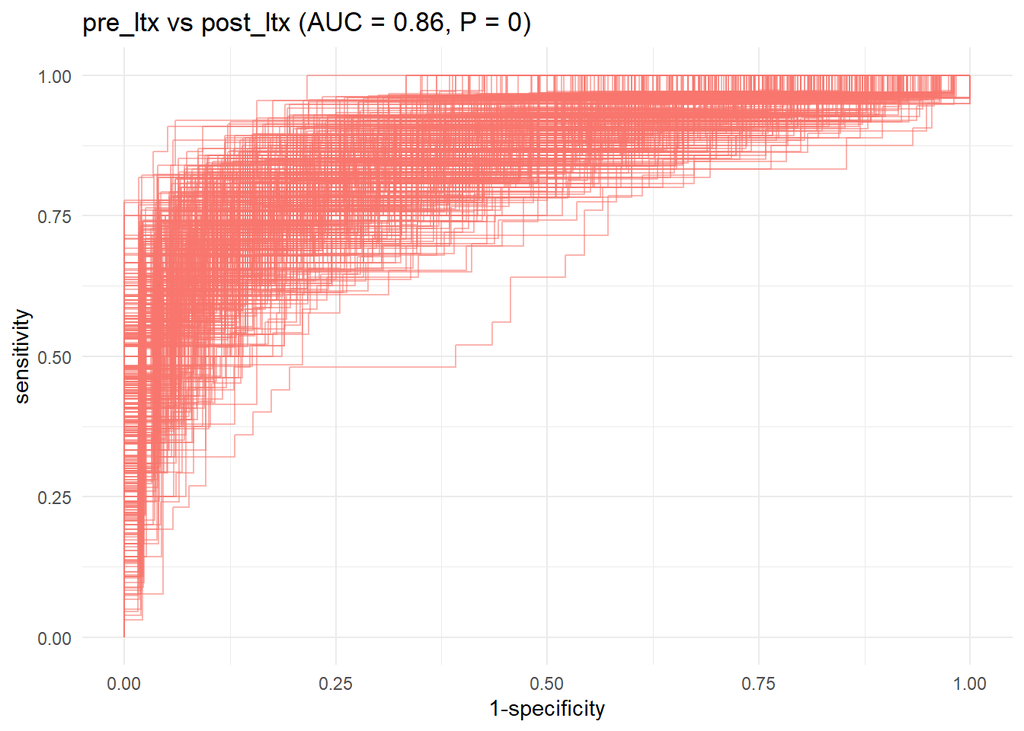

```r
roc_c
```

##### 2.5.1.1.3 post_ltx vs healthy

```r
group <- c("post_ltx","healthy")
comparison_name <- paste0(group[1], " vs ",group[2])
```

```r
model_name <- paste(comparison_name,level,segment)

# prepare the data
filt_ileum_uni_data <- binomial_prep(ileum_asv_tab,
                                     ileum_taxa_tab,
                                     ileum_metadata,
                                     group,
                                     usage="ml_clr")
```

```
Removing 641 ASV(s)
```

```
Removing 104 ASV(s)
```

```r
# fit the model
enet_model <- glmnet_binomial(filt_ileum_uni_data,
                              sample_method = "atypboot",
                              outcome="Group",
                              N=10,
                              reuse=TRUE,
                              file=model_name,
                              Q="Q1")

# ROC
roc_c <- roc_curve(enet_model, group)

# save the results
models_summ[[model_name]] <- enet_model$model_summary
models_cm[[model_name]] <- enet_model$conf_matrices$original
roc_cs[[model_name]] <- enet_model$kfold_rocobjs
betas[[model_name]] <- as.matrix(enet_model$betas)

# see the results
enet_model$model_summary %>% t()
```

```
                                      [,1]
alpha                           0.20000000
lambda                          0.04799701
auc                             1.00000000
auc_czech                       1.00000000
auc_no                          1.00000000
auc_optimism_corrected          0.95799961
auc_optimism_corrected_CIL      0.89999175
auc_optimism_corrected_CIU      0.98977781
accuracy                        1.00000000
accuracy_czech                         NaN
accuracy_no                     1.00000000
accuracy_optimism_corrected     0.89383497
accuracy_optimism_corrected_CIL 0.82118019
accuracy_optimism_corrected_CIU 0.96028870
```

```r
enet_model$conf_matrices
```

```
$original
    Predicted
True   0   1
   0  73   0
   1   0 138

$czech
    Predicted
True   0   1
   0  37   0
   1   0 102

$no
    Predicted
True  0  1
   0 36  0
   1  0 36
```

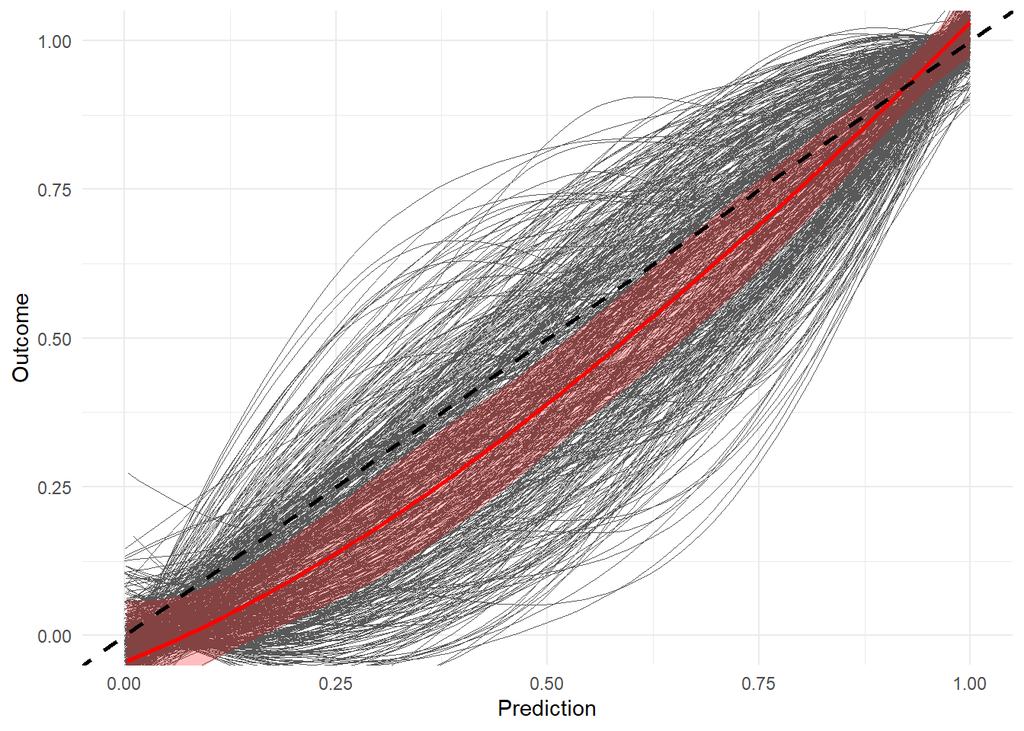

```r
enet_model$plot
```

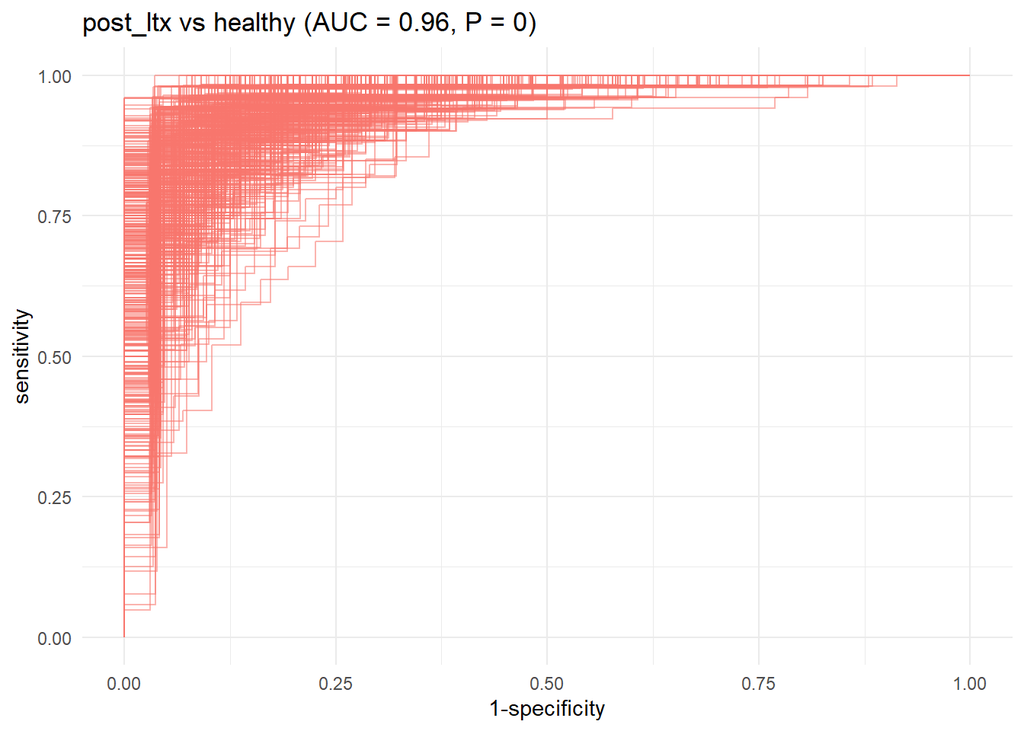

```r
roc_c
```

#### 2.5.1.2 Genus level

```r
level="genus"
```

Aggregate taxa

```r
genus_data <- aggregate_taxa(ileum_asv_tab,
                             ileum_taxa_tab,
                             taxonomic_level = level)

ileum_genus_tab <- genus_data[[1]]
ileum_genus_taxa_tab <- genus_data[[2]]
```

##### 2.5.1.2.1 pre_ltx vs healthy

```r
group <- c("pre_ltx","healthy")
comparison_name <- paste0(group[1], " vs ",group[2])
```

```r
model_name <- paste(comparison_name,level,segment)

# prepare the data
filt_ileum_uni_data <- binomial_prep(ileum_genus_tab,
                                     ileum_genus_taxa_tab,
                                     ileum_metadata,
                                     group,
                                     usage="ml_clr")
```

```
Removing 84 ASV(s)
```

```
Removing 10 ASV(s)
```

```r
# fit the model
enet_model <- glmnet_binomial(filt_ileum_uni_data,
                              sample_method = "atypboot",
                              outcome="Group",
                              N=500,
                              reuse=TRUE,
                              file=model_name,
                              Q="Q1")

# ROC
roc_c <- roc_curve(enet_model, group)

# save the results
models_summ[[model_name]] <- enet_model$model_summary
models_cm[[model_name]] <- enet_model$conf_matrices$original
roc_cs[[model_name]] <- enet_model$kfold_rocobjs
betas[[model_name]] <- as.matrix(enet_model$betas)

# see the results
enet_model$model_summary %>% t()
```

```
                                      [,1]
alpha                           0.20000000
lambda                          0.03984448
auc                             1.00000000
auc_czech                       1.00000000
auc_no                          1.00000000
auc_optimism_corrected          0.96582239
auc_optimism_corrected_CIL      0.91575521
auc_optimism_corrected_CIU      0.99568966
accuracy                        1.00000000
accuracy_czech                         NaN
accuracy_no                     1.00000000
accuracy_optimism_corrected     0.89754798
accuracy_optimism_corrected_CIL 0.80769231
accuracy_optimism_corrected_CIU 0.97141139
```

```r
enet_model$conf_matrices
```

```
$original
    Predicted
True  0  1
   0 73  0
   1  0 70

$czech
    Predicted
True  0  1
   0 37  0
   1  0 24

$no
    Predicted
True  0  1
   0 36  0
   1  0 46
```

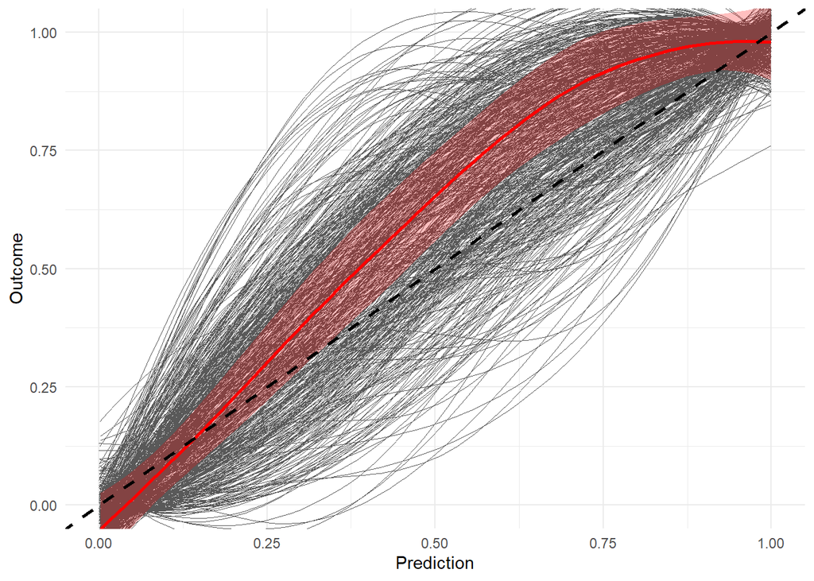

```r
enet_model$plot
```

```r
# p-value
print(paste("p_value:",mean(enet_model$valid_performances$auc_validation<0.5)*2))
```

```
[1] "p_value: 0"
```

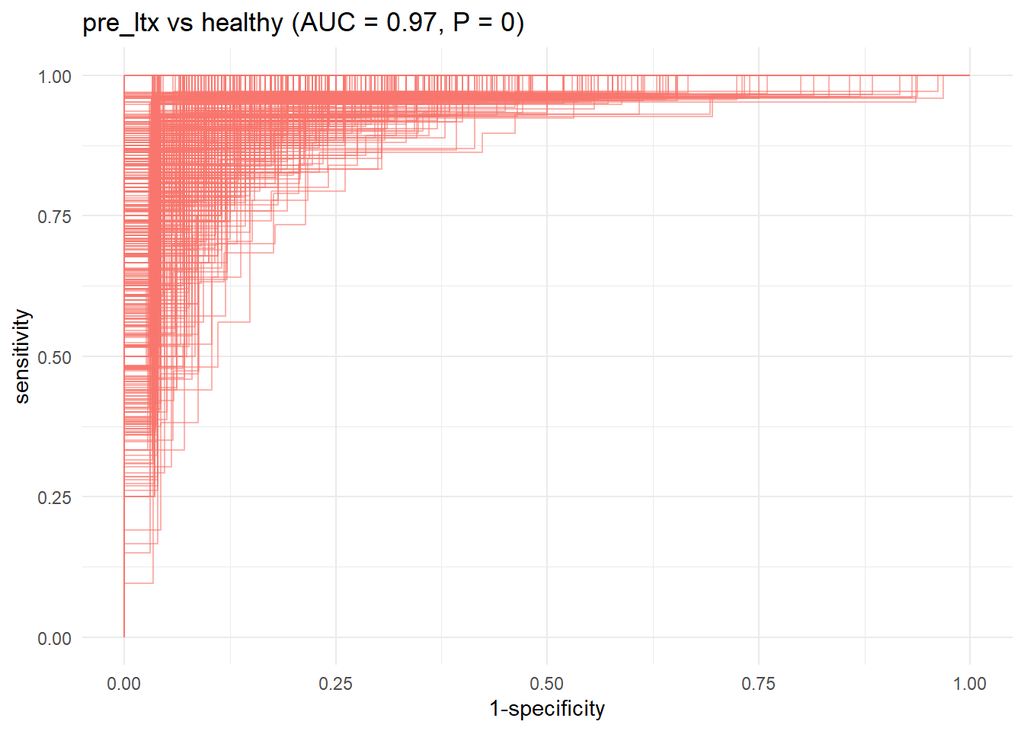

```r
roc_c
```

##### 2.5.1.2.2 pre_ltx vs post_ltx

```r
group <- c("pre_ltx","post_ltx")
comparison_name <- paste0(group[1], " vs ",group[2])
```

```r
model_name <- paste(comparison_name,level,segment)

# prepare the data
filt_ileum_uni_data <- binomial_prep(ileum_genus_tab,
                                     ileum_genus_taxa_tab,
                                     ileum_metadata,
                                     group,
                                     usage="ml_clr")
```

```
Removing 46 ASV(s)
```

```
Removing 6 ASV(s)
```

```r
# fit the model
enet_model <- glmnet_binomial(filt_ileum_uni_data,
                              sample_method = "atypboot",
                              outcome="Group", N=10,
                              reuse=TRUE,
                              file=model_name,
                              Q="Q1")

# ROC
roc_c <- roc_curve(enet_model, group)

# save the results
models_summ[[model_name]] <- enet_model$model_summary
models_cm[[model_name]] <- enet_model$conf_matrices$original
roc_cs[[model_name]] <- enet_model$kfold_rocobjs
betas[[model_name]] <- as.matrix(enet_model$betas)

# see the results
enet_model$model_summary %>% t()
```

```
                                     [,1]
alpha                           0.0000000
lambda                          0.6674012
auc                             0.9726708
auc_czech                       0.9616013
auc_no                          0.9800725
auc_optimism_corrected          0.8344709
auc_optimism_corrected_CIL      0.7487803
auc_optimism_corrected_CIU      0.9154473
accuracy                        0.8653846
accuracy_czech                        NaN
accuracy_no                     0.8780488
accuracy_optimism_corrected     0.7788698
accuracy_optimism_corrected_CIL 0.6973684
accuracy_optimism_corrected_CIU 0.8516141
```

```r
enet_model$conf_matrices
```

```
$original
    Predicted
True   0   1
   0 136   2
   1  26  44

$czech
    Predicted
True   0   1
   0 101   1
   1  17   7

$no
    Predicted
True  0  1
   0 35  1
   1  9 37
```

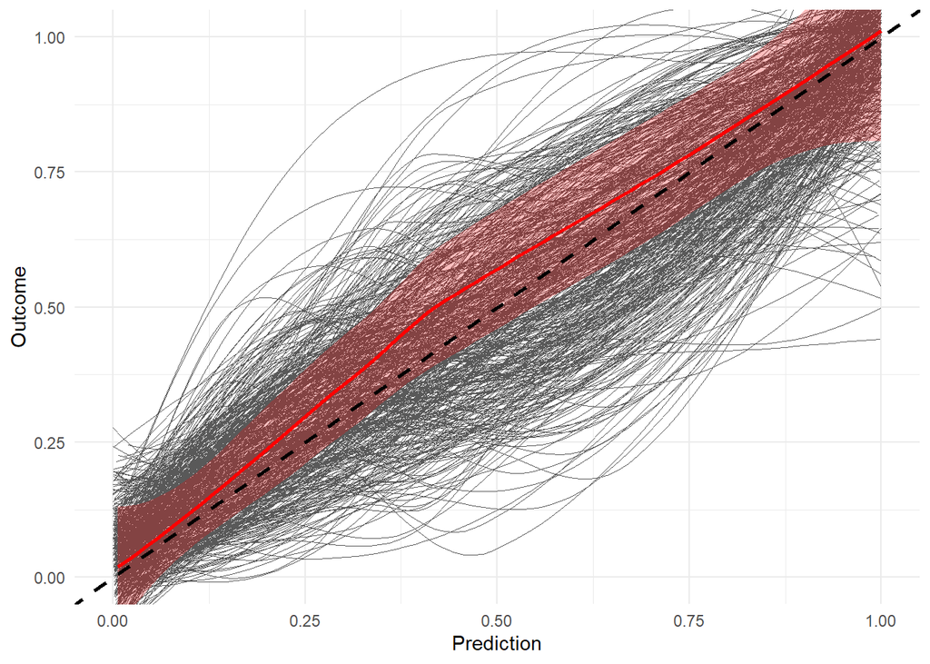

```r
enet_model$plot
```

```r
# p-value
print(paste("p_value:",mean(enet_model$valid_performances$auc_validation<0.5)*2))
```

```
[1] "p_value: 0"
```

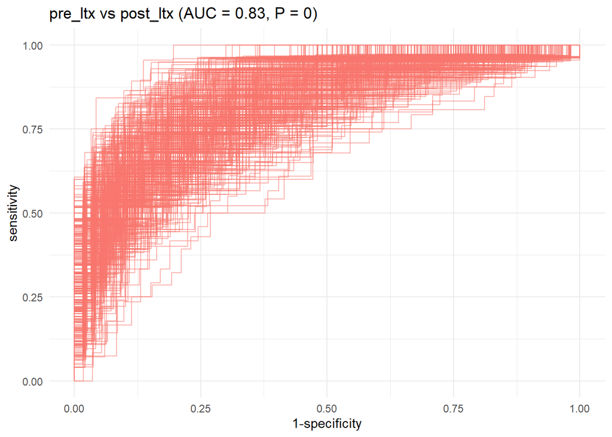

```r
roc_c
```

##### 2.5.1.2.3 post_ltx vs healthy

```r
group <- c("post_ltx","healthy")
comparison_name <- paste0(group[1], " vs ",group[2])
```

```r
model_name <- paste(comparison_name,level,segment)

# prepare the data
filt_ileum_uni_data <- binomial_prep(ileum_genus_tab,
                                     ileum_genus_taxa_tab,
                                     ileum_metadata,group,
                                     usage="ml_clr")
```

```
Removing 45 ASV(s)
```

```
Removing 2 ASV(s)
```

```r
# fit the model
enet_model <- glmnet_binomial(filt_ileum_uni_data,
                              sample_method = "atypboot",
                              outcome="Group",
                              N=10,
                              reuse=TRUE,
                              file=model_name,
                              Q="Q1")

# ROC
roc_c <- roc_curve(enet_model, group)

# save the results
models_summ[[model_name]] <- enet_model$model_summary
models_cm[[model_name]] <- enet_model$conf_matrices$original
roc_cs[[model_name]] <- enet_model$kfold_rocobjs
betas[[model_name]] <- as.matrix(enet_model$betas)

# see the results
enet_model$model_summary %>% t()
```

```
                                      [,1]
alpha                           0.00000000
lambda                          0.07097722
auc                             1.00000000
auc_czech                       1.00000000
auc_no                          1.00000000
auc_optimism_corrected          0.96566611
auc_optimism_corrected_CIL      0.92200341
auc_optimism_corrected_CIU      0.99386451
accuracy                        1.00000000
accuracy_czech                         NaN
accuracy_no                     1.00000000
accuracy_optimism_corrected     0.90031834
accuracy_optimism_corrected_CIL 0.82800926
accuracy_optimism_corrected_CIU 0.96054545
```

```r
enet_model$conf_matrices
```

```
$original
    Predicted
True   0   1
   0  73   0
   1   0 138

$czech
    Predicted
True   0   1
   0  37   0
   1   0 102

$no
    Predicted
True  0  1
   0 36  0
   1  0 36
```

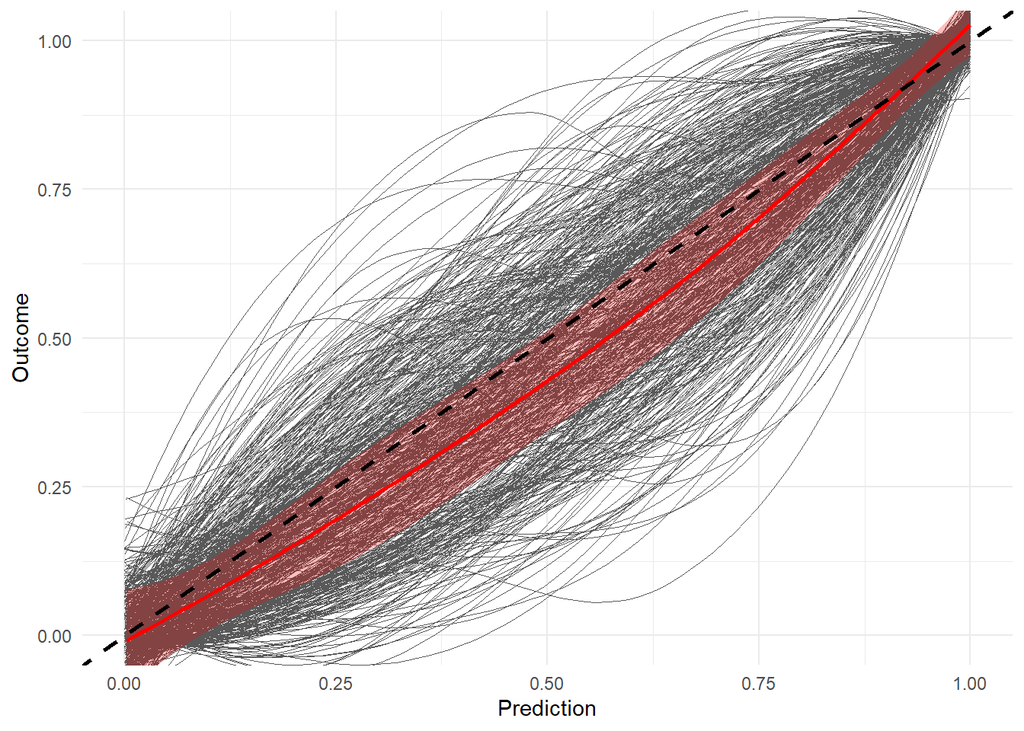

```r
enet_model$plot
```

```r
# p-value
print(paste("p_value:",mean(enet_model$valid_performances$auc_validation<0.5)*2))
```

```
[1] "p_value: 0"
```

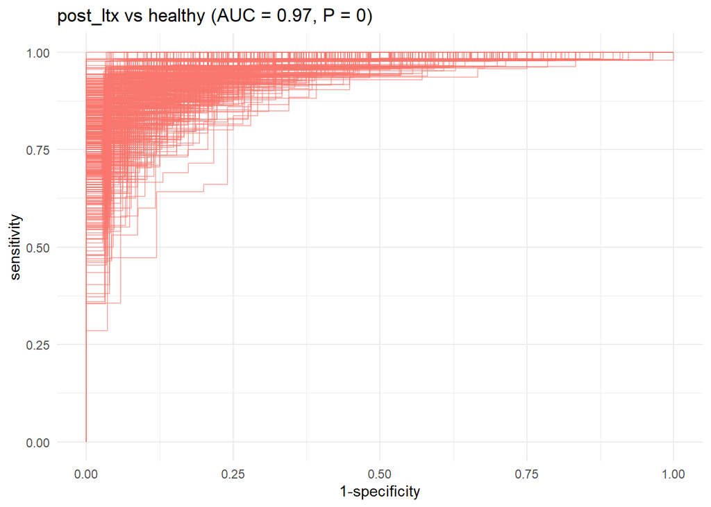

```r
roc_c
```

#### 2.5.1.3 Saving results

```r
models_summ_df_ileum <- do.call(rbind,
  models_summ[grep(segment,names(models_summ),value = TRUE)])

write.csv(models_summ_df_ileum,file.path(path,paste0("elastic_net_",segment,".csv")))
```

### 2.5.2 Supplementary models

```r
supplements_models <- list()
```

#### 2.5.2.1 CLR-transformed data

##### 2.5.2.1.1 kNN

```r
model="knn"
```

###### 2.5.2.1.1.1 ASV level

```r
level="ASV"
```

*pre_ltx vs healthy*

```r
group <- c("pre_ltx","healthy")
comparison_name <- paste0(group[1], " vs ",group[2])
```

```r
model_name <- paste(comparison_name,level,segment)

# prepare the data
filt_ileum_uni_data <- binomial_prep(ileum_asv_tab,
                                     ileum_taxa_tab,
                                     ileum_metadata,
                                     group, usage="ml_clr")
```

```
Removing 1598 ASV(s)
```

```
Removing 146 ASV(s)
```

```r
# fit the model
knn_model <- knn_binomial(filt_ileum_uni_data,
                              sample_method = "atypboot",
                              outcome="Group",
                              N=10,
                              reuse=TRUE,
                              file=model_name,
                              Q="Q1")

# ROC curve
roc_c <- roc_curve(knn_model, group)

# save the results
supplements_models[["models_summ"]][["knn_model"]][[model_name]] <- knn_model$model_summary
supplements_models[["roc_cs"]][["knn_model"]][[model_name]] <- knn_model$kfold_rocobjs

# see the results
knn_model$model_summary %>% t()
```

```
                                      [,1]
k                               18.0000000
auc                              0.9239726
auc_optimism_corrected           0.8707255
auc_optimism_corrected_CIL       0.7611443
auc_optimism_corrected_CIU       0.9538139
accuracy                         0.7762238
accuracy_optimism_corrected      0.7606251
accuracy_optimism_corrected_CIL  0.6400000
accuracy_optimism_corrected_CIU  0.8714046
```

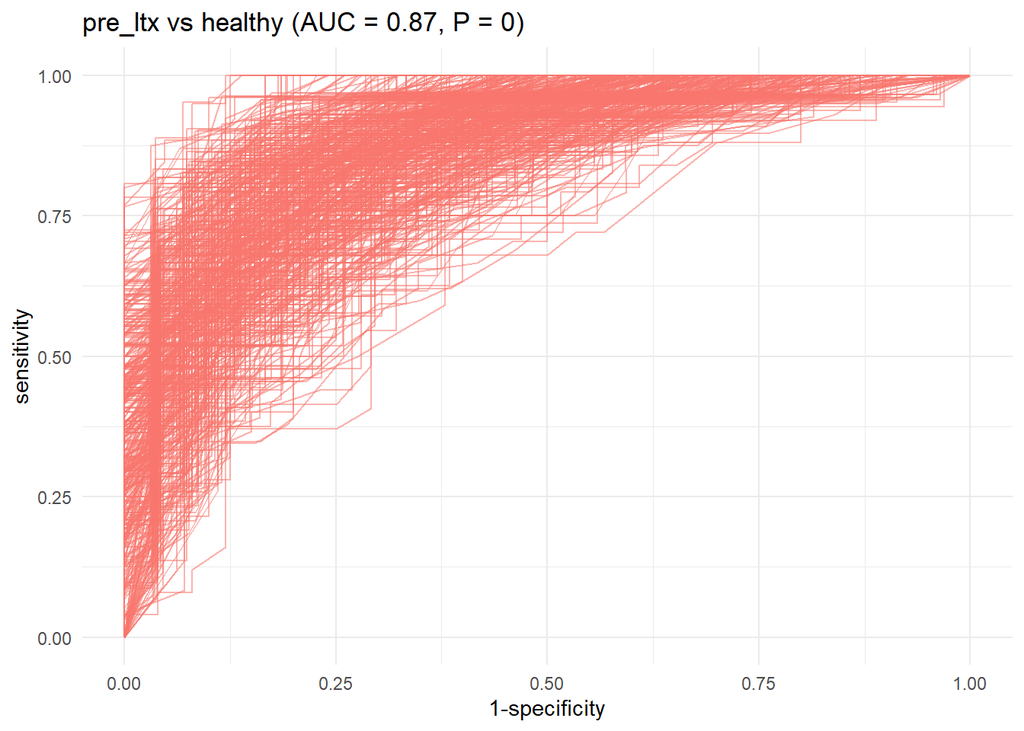

```r
roc_c
```

**pre_ltx vs post_ltx**

```r
group <- c("pre_ltx","post_ltx")
comparison_name <- paste0(group[1], " vs ",group[2])
```

```r
model_name <- paste(comparison_name,level,segment)


# prepare the data
filt_ileum_uni_data <- binomial_prep(ileum_asv_tab,
                                     ileum_taxa_tab,
                                     ileum_metadata,
                                     group, usage="ml_clr")
```

```
Removing 979 ASV(s)
```

```
Removing 68 ASV(s)
```

```r
# fit the model
knn_model <- knn_binomial(filt_ileum_uni_data,
                              sample_method = "atypboot",
                              outcome="Group",
                              N=10,
                              reuse=TRUE,
                              file=model_name,
                              Q="Q1")

# ROC curve
roc_c <- roc_curve(knn_model, group)

# save the results
supplements_models[["models_summ"]][["knn_model"]][[model_name]] <- knn_model$model_summary
supplements_models[["roc_cs"]][["knn_model"]][[model_name]] <- knn_model$kfold_rocobjs


# see the results
knn_model$model_summary %>% t()
```

```
                                      [,1]
k                               16.0000000
auc                              0.8342650
auc_optimism_corrected           0.6861098
auc_optimism_corrected_CIL       0.5546110
auc_optimism_corrected_CIU       0.7936124
accuracy                         0.7067308
accuracy_optimism_corrected      0.6707627
accuracy_optimism_corrected_CIL  0.5697674
accuracy_optimism_corrected_CIU  0.7682297
```

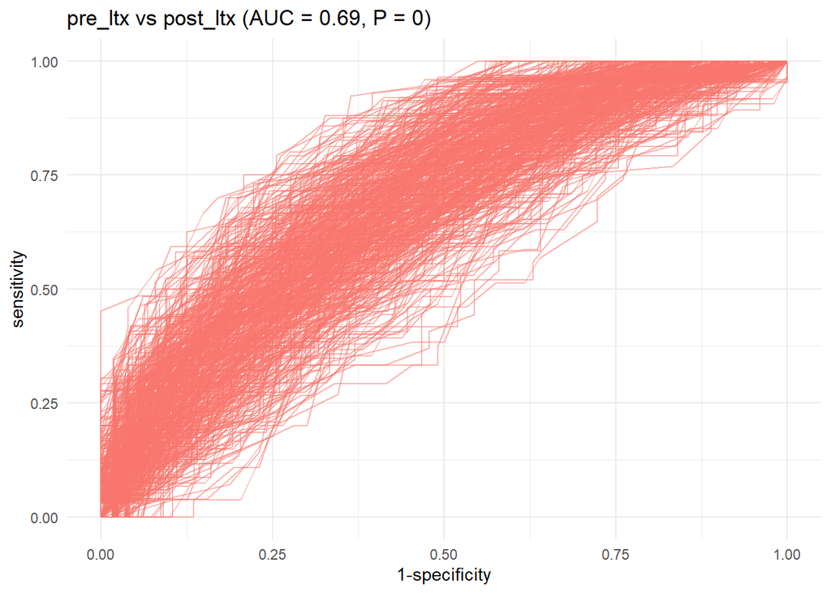

```r
roc_c
```

**post_ltx vs healthy**

```r
group <- c("post_ltx","healthy")
comparison_name <- paste0(group[1], " vs ",group[2])
```

```r
model_name <- paste(comparison_name,level,segment)

# prepare the data
filt_ileum_uni_data <- binomial_prep(ileum_asv_tab,
                                     ileum_taxa_tab,
                                     ileum_metadata,
                                     group, usage="ml_clr")
```

```
Removing 641 ASV(s)
```

```
Removing 104 ASV(s)
```

```r
# fit the model
knn_model <- knn_binomial(filt_ileum_uni_data,
                              sample_method = "atypboot",
                              outcome="Group",
                              N=10,
                              reuse=TRUE,
                              file=model_name,
                              Q="Q1")

# ROC curve
roc_c <- roc_curve(knn_model, group)

# save the results
# save the results
supplements_models[["models_summ"]][["knn_model"]][[model_name]] <- knn_model$model_summary
supplements_models[["roc_cs"]][["knn_model"]][[model_name]] <- knn_model$kfold_rocobjs

# see the results
knn_model$model_summary %>% t()
```

```
                                      [,1]
k                               27.0000000
auc                              0.9100159
auc_optimism_corrected           0.8695718
auc_optimism_corrected_CIL       0.7804090
auc_optimism_corrected_CIU       0.9534194
accuracy                         0.8720379
accuracy_optimism_corrected      0.8197023
accuracy_optimism_corrected_CIL  0.7302235
accuracy_optimism_corrected_CIU  0.8972568
```

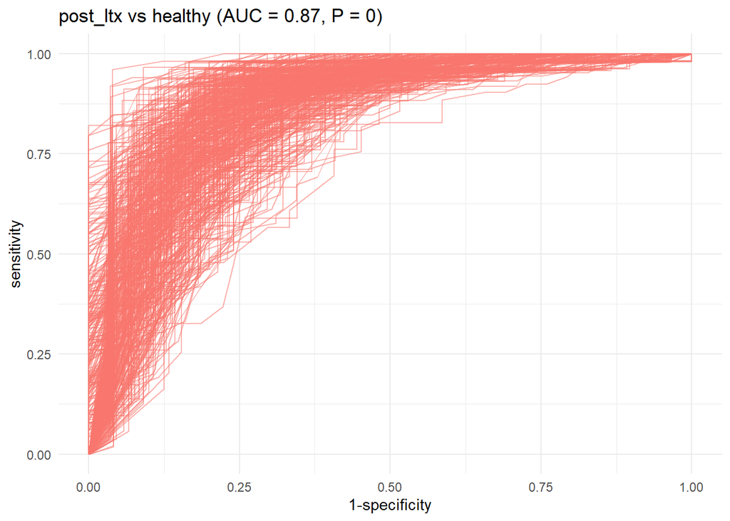

```r
roc_c
```

###### 2.5.2.1.1.2 Genus level

```r
level="genus"
```

Aggregate taxa

```r
genus_data <- aggregate_taxa(ileum_asv_tab,
                             ileum_taxa_tab,
                             taxonomic_level = level)

ileum_genus_tab <- genus_data[[1]]
ileum_genus_taxa_tab <- genus_data[[2]]
```

**pre_ltx vs healthy**

```r
group <- c("pre_ltx","healthy")
comparison_name <- paste0(group[1], " vs ",group[2])
```

```r
model_name <- paste(comparison_name,level,segment)

# prepare the data
filt_ileum_uni_data <- binomial_prep(ileum_genus_tab,
                                     ileum_genus_taxa_tab,
                                     ileum_metadata,
                                     group,
                                     usage="ml_clr")
```

```
Removing 84 ASV(s)
```

```
Removing 10 ASV(s)
```

```r
# fit the model
knn_model <- knn_binomial(filt_ileum_uni_data,
                              sample_method = "atypboot",
                              outcome="Group",
                              N=10,
                              reuse=TRUE,
                              file=model_name,
                              Q="Q1")

# ROC curve
roc_c <- roc_curve(knn_model, group)

# save the results
supplements_models[["models_summ"]][["knn_model"]][[model_name]] <- knn_model$model_summary
supplements_models[["roc_cs"]][["knn_model"]][[model_name]] <- knn_model$kfold_rocobjs

# p-value
print(paste("p_value:",mean(knn_model$valid_performances$auc_validation<0.5)*2))
```

```
[1] "p_value: 0"
```

```r
# see the results
knn_model$model_summary %>% t()
```

```
                                      [,1]
k                               12.0000000
auc                              0.9568493
auc_optimism_corrected           0.8867898
auc_optimism_corrected_CIL       0.7995277
auc_optimism_corrected_CIU       0.9600000
accuracy                         0.7692308
accuracy_optimism_corrected      0.7505565
accuracy_optimism_corrected_CIL  0.6074755
accuracy_optimism_corrected_CIU  0.8600000
```

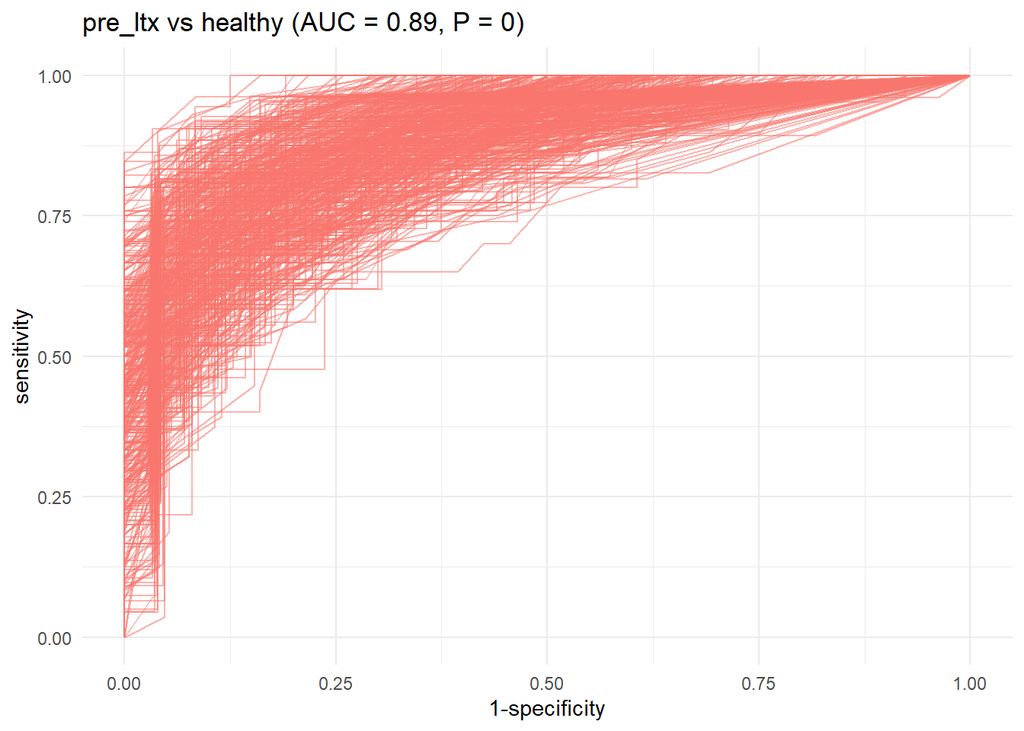

```r
roc_c
```

**pre_ltx vs post_ltx**

```r
group <- c("pre_ltx","post_ltx")
comparison_name <- paste0(group[1], " vs ",group[2])
```

```r
model_name <- paste(comparison_name,level,segment)

# prepare the data
filt_ileum_uni_data <- binomial_prep(ileum_genus_tab,
                                     ileum_genus_taxa_tab,
                                     ileum_metadata,
                                     group,
                                     usage="ml_clr")
```

```
Removing 46 ASV(s)
```

```
Removing 6 ASV(s)
```

```r
# fit the model
knn_model <- knn_binomial(filt_ileum_uni_data,
                              sample_method = "atypboot",
                              outcome="Group",
                              N=10,
                              reuse=TRUE,
                              file=model_name,
                              Q="Q1")

# ROC curve
roc_c <- roc_curve(knn_model, group)

# save the results
supplements_models[["models_summ"]][["knn_model"]][[model_name]] <- knn_model$model_summary
supplements_models[["roc_cs"]][["knn_model"]][[model_name]] <- knn_model$kfold_rocobjs

# see the results
knn_model$model_summary %>% t()
```

```
                                      [,1]
k                               17.0000000
auc                              0.8493789
auc_optimism_corrected           0.7274604
auc_optimism_corrected_CIL       0.6082378
auc_optimism_corrected_CIU       0.8332776
accuracy                         0.7692308
accuracy_optimism_corrected      0.6961743
accuracy_optimism_corrected_CIL  0.5961806
accuracy_optimism_corrected_CIU  0.7950340
```

```r
# p-value
print(paste("p_value:",mean(knn_model$valid_performances$auc_validation<0.5)*2))
```

```
[1] "p_value: 0"
```

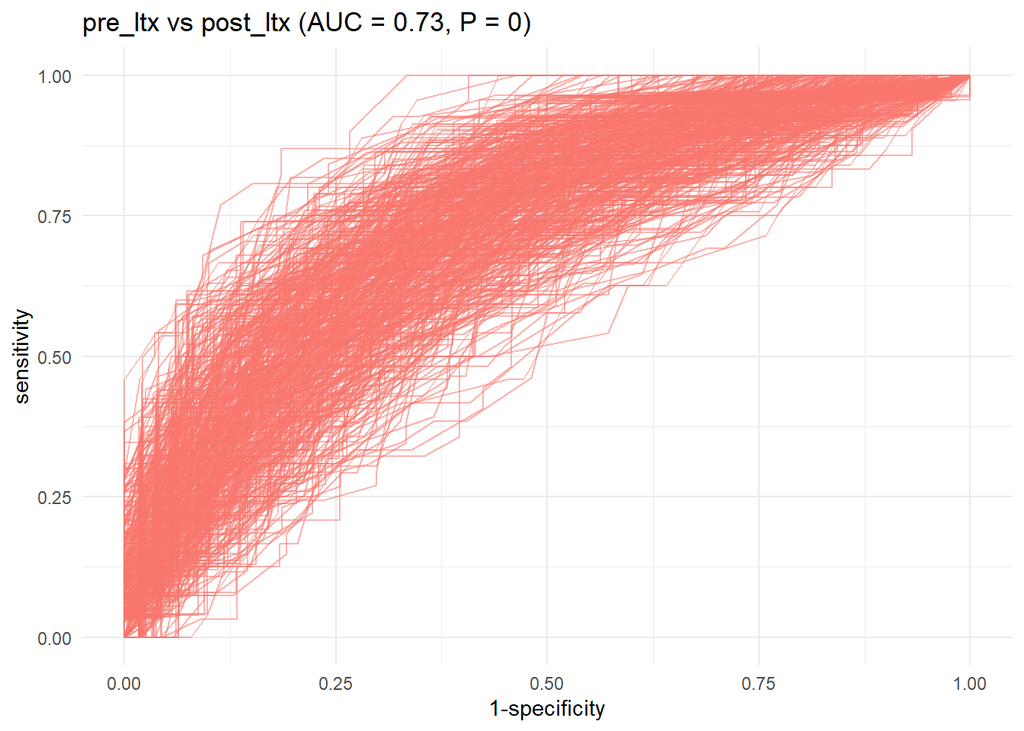

```r
roc_c
```

**post_ltx vs healthy**

```r
group <- c("post_ltx","healthy")
comparison_name <- paste0(group[1], " vs ",group[2])
```

```r
model_name <- paste(comparison_name,level,segment)

# prepare the data
filt_ileum_uni_data <- binomial_prep(ileum_genus_tab,
                                     ileum_genus_taxa_tab,
                                     ileum_metadata,
                                     group,
                                     usage="ml_clr")
```

```
Removing 45 ASV(s)
```

```
Removing 2 ASV(s)
```

```r
# fit the model
knn_model <- knn_binomial(filt_ileum_uni_data,
                              sample_method = "atypboot",
                              outcome="Group",
                              N=10,
                              reuse=TRUE,
                              file=model_name,
                              Q="Q1")

# ROC curve
roc_c <- roc_curve(knn_model, group)

# save the results
supplements_models[["models_summ"]][["knn_model"]][[model_name]] <- knn_model$model_summary
supplements_models[["roc_cs"]][["knn_model"]][[model_name]] <- knn_model$kfold_rocobjs


# see the results
knn_model$model_summary %>% t()
```

```
                                      [,1]
k                               12.0000000
auc                              0.9638674
auc_optimism_corrected           0.9214737
auc_optimism_corrected_CIL       0.8567085
auc_optimism_corrected_CIU       0.9739614
accuracy                         0.8530806
accuracy_optimism_corrected      0.7997011
accuracy_optimism_corrected_CIL  0.6820732
accuracy_optimism_corrected_CIU  0.8987821
```

```r
# p-value
print(paste("p_value:",mean(knn_model$valid_performances$auc_validation<0.5)*2))
```

```
[1] "p_value: 0"
```

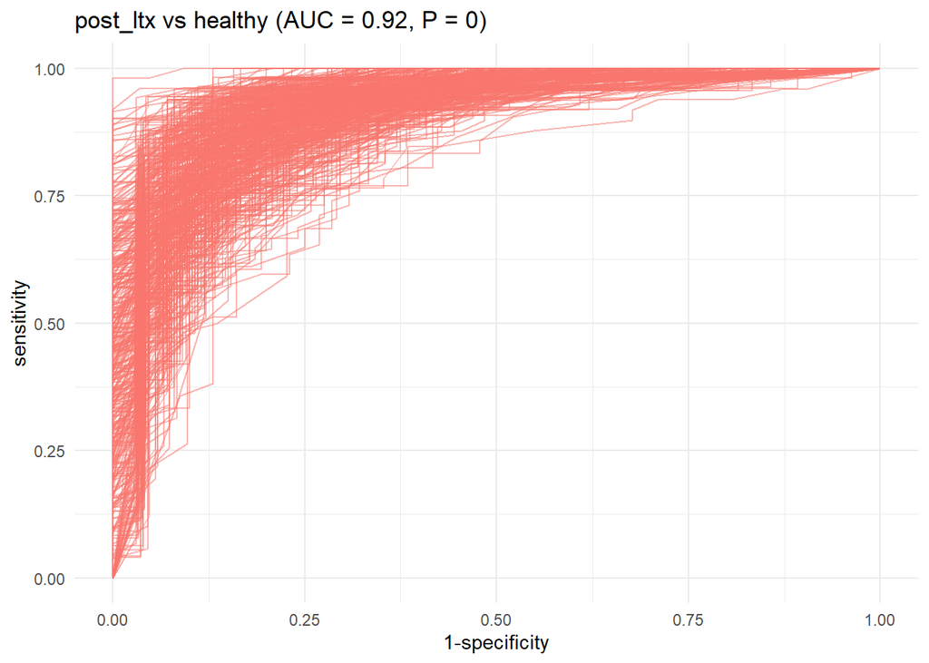

```r
roc_c
```

##### 2.5.2.1.2 RF

```r
model="rf"
```

###### 2.5.2.1.2.1 ASV level

```r
level="ASV"
```

*pre_ltx vs healthy*

```r
group <- c("pre_ltx","healthy")
comparison_name <- paste0(group[1], " vs ",group[2])
```

```r
model_name <- paste(comparison_name,level,segment)

# prepare the data
filt_ileum_uni_data <- binomial_prep(ileum_asv_tab,
                                     ileum_taxa_tab,
                                     ileum_metadata,
                                     group, usage="ml_clr")
```

```
Removing 1598 ASV(s)
```

```
Removing 146 ASV(s)
```

```r
# fit the model
rf_model <- rf_binomial(filt_ileum_uni_data,
                              sample_method = "atypboot",
                              outcome="Group",
                              N=10,
                              reuse=TRUE,
                              file=model_name,
                              Q="Q1")

# ROC curve
roc_c <- roc_curve(rf_model, group)

# save the results
supplements_models[["models_summ"]][["rf_model"]][[model_name]] <- rf_model$model_summary
supplements_models[["roc_cs"]][["rf_model"]][[model_name]] <- rf_model$kfold_rocobjs

# see the results
rf_model$model_summary %>% t()
```

```
                                [,1]
mtry                            "105"
splitrule                       "gini"
min.node.size                   "2"
auc                             "1"
auc_optimism_corrected          "0.946523"
auc_optimism_corrected_CIL      "0.8726572"
auc_optimism_corrected_CIU      "0.9949915"
accuracy                        "1"
accuracy_optimism_corrected     "0.868117"
accuracy_optimism_corrected_CIL "0.7609048"
accuracy_optimism_corrected_CIU "0.960024"
```

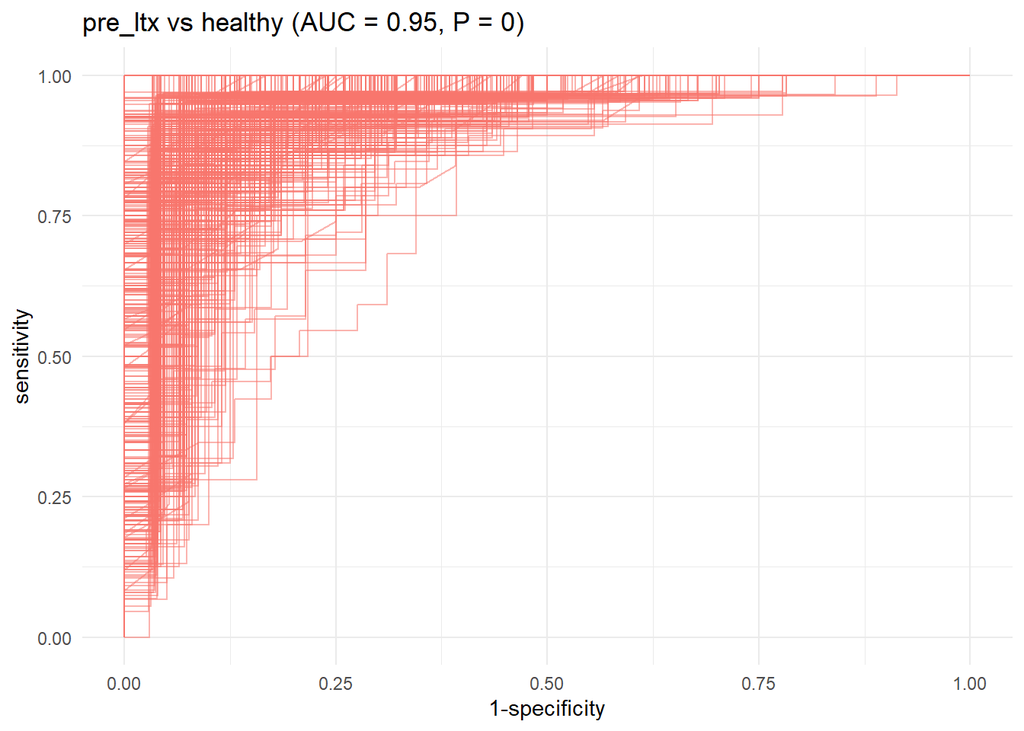

```r
roc_c
```

**pre_ltx vs post_ltx**

```r
group <- c("pre_ltx","post_ltx")
comparison_name <- paste0(group[1], " vs ",group[2])
```

```r
model_name <- paste(comparison_name,level,segment)

# prepare the data
filt_ileum_uni_data <- binomial_prep(ileum_asv_tab,
                                     ileum_taxa_tab,
                                     ileum_metadata,
                                     group, usage="ml_clr")
```

```
Removing 979 ASV(s)
```

```
Removing 68 ASV(s)
```

```r
# fit the model
rf_model <- rf_binomial(filt_ileum_uni_data,
                              sample_method = "atypboot",
                              outcome="Group",
                              N=10,
                              reuse=TRUE,
                              file=model_name,
                              Q="Q1")

# ROC curve
roc_c <- roc_curve(rf_model, group)

# save the results
supplements_models[["models_summ"]][["rf_model"]][[model_name]] <- rf_model$model_summary
supplements_models[["roc_cs"]][["rf_model"]][[model_name]] <- rf_model$kfold_rocobjs

# see the results
rf_model$model_summary %>% t()
```

```
                                [,1]
mtry                            "115"
splitrule                       "gini"
min.node.size                   "5"
auc                             "1"
auc_optimism_corrected          "0.8555864"
auc_optimism_corrected_CIL      "0.7560028"
auc_optimism_corrected_CIU      "0.941253"
accuracy                        "1"
accuracy_optimism_corrected     "0.8330184"
accuracy_optimism_corrected_CIL "0.7464789"
accuracy_optimism_corrected_CIU "0.9102992"
```

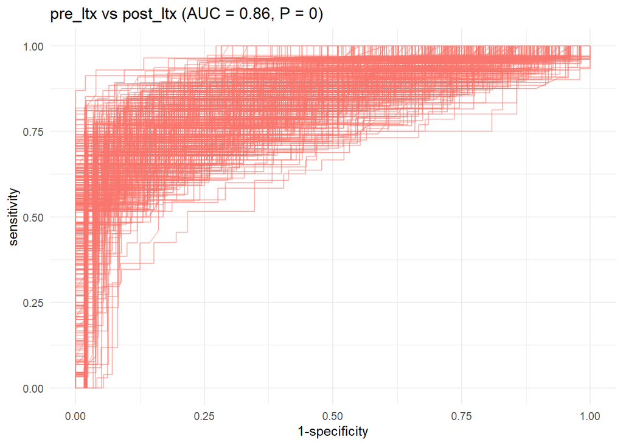

```r
roc_c
```

**post_ltx vs healthy**

```r
group <- c("post_ltx","healthy")
comparison_name <- paste0(group[1], " vs ",group[2])
```

```r
model_name <- paste(comparison_name,level,segment)

# prepare the data
filt_ileum_uni_data <- binomial_prep(ileum_asv_tab,
                                     ileum_taxa_tab,
                                     ileum_metadata,
                                     group, usage="ml_clr")
```

```
Removing 641 ASV(s)
```

```
Removing 104 ASV(s)
```

```r
# fit the model
rf_model <- rf_binomial(filt_ileum_uni_data,
                              sample_method = "atypboot",
                              outcome="Group",
                              N=10,
                              reuse=TRUE,
                              file=model_name,
                              Q="Q1")

# ROC curve
roc_c <- roc_curve(rf_model, group)

# save the results
supplements_models[["models_summ"]][["rf_model"]][[model_name]] <- rf_model$model_summary
supplements_models[["roc_cs"]][["rf_model"]][[model_name]] <- rf_model$kfold_rocobjs

# see the results
rf_model$model_summary %>% t()
```

```
                                [,1]
mtry                            "115"
splitrule                       "gini"
min.node.size                   "2"
auc                             "1"
auc_optimism_corrected          "0.8996574"
auc_optimism_corrected_CIL      "0.8172801"
auc_optimism_corrected_CIU      "0.9705953"
accuracy                        "1"
accuracy_optimism_corrected     "0.874331"
accuracy_optimism_corrected_CIL "0.7870625"
accuracy_optimism_corrected_CIU "0.9412131"
```

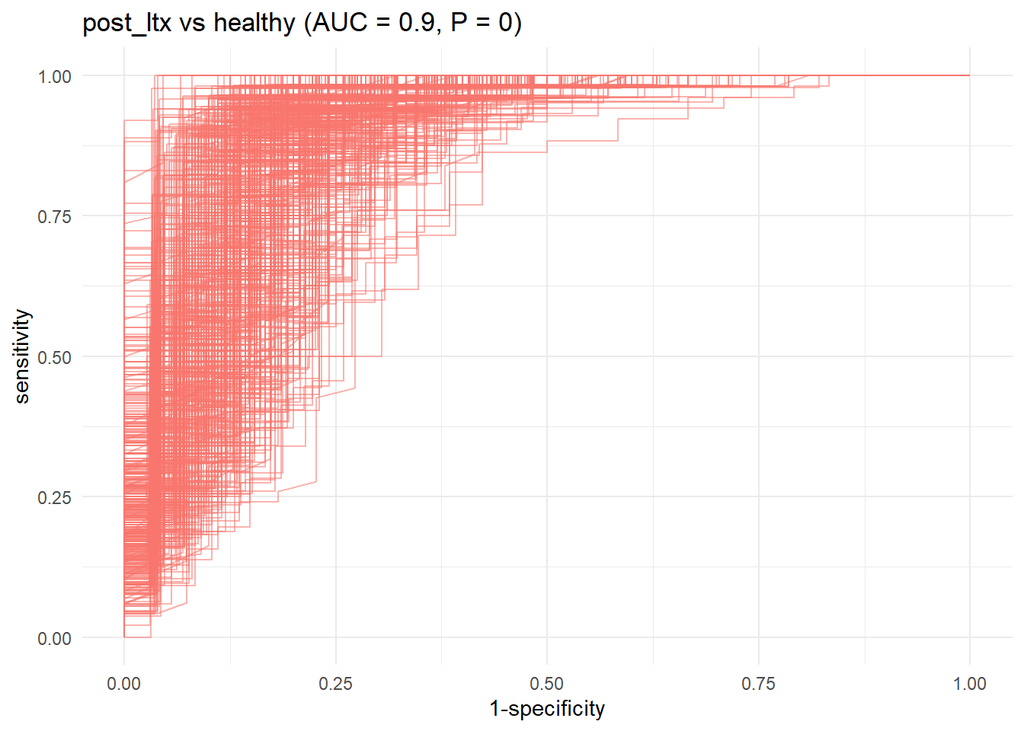

```r
roc_c
```

###### 2.5.2.1.2.2 Genus level

```r
level="genus"
```

Aggregate taxa

```r
genus_data <- aggregate_taxa(ileum_asv_tab,
                             ileum_taxa_tab,
                             taxonomic_level = level)

ileum_genus_tab <- genus_data[[1]]
ileum_genus_taxa_tab <- genus_data[[2]]
```

**pre_ltx vs healthy**

```r
group <- c("pre_ltx","healthy")
comparison_name <- paste0(group[1], " vs ",group[2])
```

```r
model_name <- paste(comparison_name,level,segment)

# prepare the data
filt_ileum_uni_data <- binomial_prep(ileum_genus_tab,
                                     ileum_genus_taxa_tab,
                                     ileum_metadata,
                                     group,
                                     usage="ml_clr")
```

```
Removing 84 ASV(s)
```

```
Removing 10 ASV(s)
```

```r
# fit the model
rf_model <- rf_binomial(filt_ileum_uni_data,
                              sample_method = "atypboot",
                              outcome="Group",
                              N=10,
                              reuse=TRUE,
                              file=model_name,
                              Q="Q1")

# ROC curve
roc_c <- roc_curve(rf_model, group)

# save the results
supplements_models[["models_summ"]][["rf_model"]][[model_name]] <- rf_model$model_summary
supplements_models[["roc_cs"]][["rf_model"]][[model_name]] <- rf_model$kfold_rocobjs

# see the results
rf_model$model_summary %>% t()
```

```
                                [,1]
mtry                            "47"
splitrule                       "gini"
min.node.size                   "5"
auc                             "1"
auc_optimism_corrected          "0.9495441"
auc_optimism_corrected_CIL      "0.8771007"
auc_optimism_corrected_CIU      "0.9959453"
accuracy                        "1"
accuracy_optimism_corrected     "0.8764871"
accuracy_optimism_corrected_CIL "0.7804167"
accuracy_optimism_corrected_CIU "0.9615385"
```

```r
# p-value
print(paste("p_value:",mean(rf_model$valid_performances$auc_validation<0.5)*2))
```

```
[1] "p_value: 0"
```

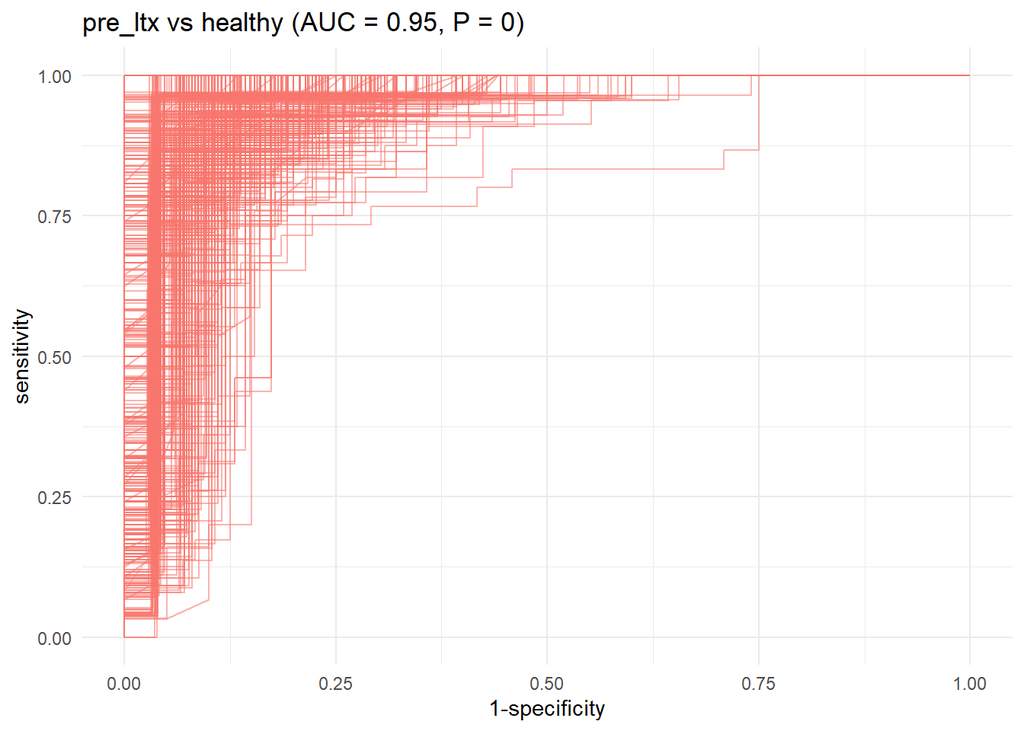

```r
roc_c
```

**pre_ltx vs post_ltx**

```r
group <- c("pre_ltx","post_ltx")
comparison_name <- paste0(group[1], " vs ",group[2])
```

```r
model_name <- paste(comparison_name,level,segment)

# prepare the data
filt_ileum_uni_data <- binomial_prep(ileum_genus_tab,
                                     ileum_genus_taxa_tab,
                                     ileum_metadata,
                                     group,
                                     usage="ml_clr")
```

```
Removing 46 ASV(s)
```

```
Removing 6 ASV(s)
```

```r
# fit the model
rf_model <- rf_binomial(filt_ileum_uni_data,
                              sample_method = "atypboot",
                              outcome="Group",
                              N=10,
                              reuse=TRUE,
                              file=model_name,
                              Q="Q1")

# ROC curve
roc_c <- roc_curve(rf_model, group)

# save the results
supplements_models[["models_summ"]][["rf_model"]][[model_name]] <- rf_model$model_summary
supplements_models[["roc_cs"]][["rf_model"]][[model_name]] <- rf_model$kfold_rocobjs

# see the results
rf_model$model_summary %>% t()
```

```
                                [,1]
mtry                            "57"
splitrule                       "gini"
min.node.size                   "2"
auc                             "1"
auc_optimism_corrected          "0.8244378"
auc_optimism_corrected_CIL      "0.7188584"
auc_optimism_corrected_CIU      "0.9062878"
accuracy                        "1"
accuracy_optimism_corrected     "0.79629"
accuracy_optimism_corrected_CIL "0.7037701"
accuracy_optimism_corrected_CIU "0.8726469"
```

```r
# p-value
print(paste("p_value:",mean(rf_model$valid_performances$auc_validation<0.5)*2))
```

```
[1] "p_value: 0"
```

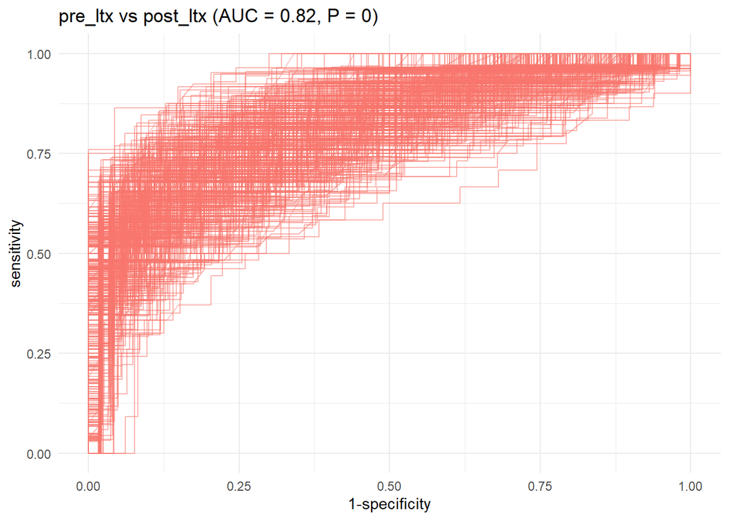

```r
roc_c
```

**post_ltx vs healthy**

```r
group <- c("post_ltx","healthy")
comparison_name <- paste0(group[1], " vs ",group[2])
```

```r
model_name <- paste(comparison_name,level,segment)

# prepare the data
filt_ileum_uni_data <- binomial_prep(ileum_genus_tab,
                                     ileum_genus_taxa_tab,
                                     ileum_metadata,
                                     group,
                                     usage="ml_clr")
```

```
Removing 45 ASV(s)
```

```
Removing 2 ASV(s)
```

```r
# fit the model
rf_model <- rf_binomial(filt_ileum_uni_data,
                              sample_method = "atypboot",
                              outcome="Group",
                              N=10,
                              reuse=TRUE,
                              file=model_name,
                              Q="Q1")

# ROC curve
roc_c <- roc_curve(rf_model, group)

# save the results
supplements_models[["models_summ"]][["rf_model"]][[model_name]] <- rf_model$model_summary
supplements_models[["roc_cs"]][["rf_model"]][[model_name]] <- rf_model$kfold_rocobjs

# see the results
rf_model$model_summary %>% t()
```

```
                                [,1]
mtry                            "133"
splitrule                       "gini"
min.node.size                   "2"
auc                             "1"
auc_optimism_corrected          "0.9117739"
auc_optimism_corrected_CIL      "0.8210604"
auc_optimism_corrected_CIU      "0.978767"
accuracy                        "1"
accuracy_optimism_corrected     "0.8682508"
accuracy_optimism_corrected_CIL "0.7820513"
accuracy_optimism_corrected_CIU "0.9421487"
```

```r
# p-value
print(paste("p_value:",mean(rf_model$valid_performances$auc_validation<0.5)*2))
```

```
[1] "p_value: 0"
```

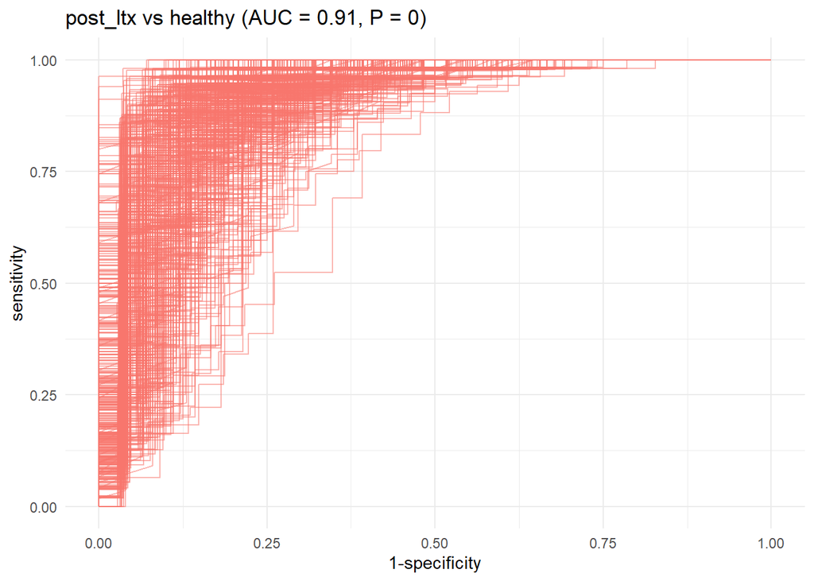

```r
roc_c
```

##### 2.5.2.1.3 Gradient boosting

```r
model="gb"
```

###### 2.5.2.1.3.1 ASV level

```r
level="ASV"
```

*pre_ltx vs healthy*

```r
group <- c("pre_ltx","healthy")
comparison_name <- paste0(group[1], " vs ",group[2])
```

```r
model_name <- paste(comparison_name,level,segment)

# prepare the data
filt_ileum_uni_data <- binomial_prep(ileum_asv_tab,
                                     ileum_taxa_tab,
                                     ileum_metadata,
                                     group, usage="ml_clr")
```

```
Removing 1598 ASV(s)
```

```
Removing 146 ASV(s)
```

```r
# fit the model
gbm_model <- gbm_binomial(filt_ileum_uni_data,
                              sample_method = "atypboot",
                              outcome="Group",
                              N=10,
                              reuse=TRUE,
                              file=model_name,
                              Q="Q1")

# ROC curve
roc_c <- roc_curve(gbm_model, group)

# save the results
supplements_models[["models_summ"]][["gbm_model"]][[model_name]] <- gbm_model$model_summary
supplements_models[["roc_cs"]][["gbm_model"]][[model_name]] <- gbm_model$kfold_rocobjs

# see the results
gbm_model$model_summary %>% t()
```

```
                                       [,1]
n.trees                         500.0000000
interaction.depth                 1.0000000
shrinkage                         0.1000000
n.minobsinnode                   20.0000000
auc                               1.0000000
auc_optimism_corrected            0.9548905
auc_optimism_corrected_CIL        0.9022039
auc_optimism_corrected_CIU        0.9919377
accuracy                          1.0000000
accuracy_optimism_corrected       0.8793789
accuracy_optimism_corrected_CIL   0.7884615
accuracy_optimism_corrected_CIU   0.9604118
```

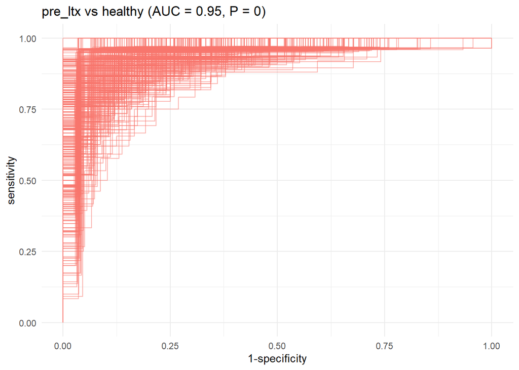

```r
roc_c
```

**pre_ltx vs post_ltx**

```r
group <- c("pre_ltx","post_ltx")
comparison_name <- paste0(group[1], " vs ",group[2])
```

```r
model_name <- paste(comparison_name,level,segment)

# prepare the data
filt_ileum_uni_data <- binomial_prep(ileum_asv_tab,
                                     ileum_taxa_tab,
                                     ileum_metadata,
                                     group, usage="ml_clr")
```

```
Removing 979 ASV(s)
```

```
Removing 68 ASV(s)
```

```r
# fit the model
gbm_model <- gbm_binomial(filt_ileum_uni_data,
                              sample_method = "atypboot",
                              outcome="Group",
                              N=10,
                              reuse=TRUE,
                              file=model_name,
                              Q="Q1")

# ROC curve
roc_c <- roc_curve(gbm_model, group)

# save the results
supplements_models[["models_summ"]][["gbm_model"]][[model_name]] <- gbm_model$model_summary
supplements_models[["roc_cs"]][["gbm_model"]][[model_name]] <- gbm_model$kfold_rocobjs


# see the results
gbm_model$model_summary %>% t()
```

```
                                       [,1]
n.trees                         100.0000000
interaction.depth                 5.0000000
shrinkage                         0.1000000
n.minobsinnode                   20.0000000
auc                               0.9998965
auc_optimism_corrected            0.8678054
auc_optimism_corrected_CIL        0.7868984
auc_optimism_corrected_CIU        0.9351204
accuracy                          0.9903846
accuracy_optimism_corrected       0.8340986
accuracy_optimism_corrected_CIL   0.7482500
accuracy_optimism_corrected_CIU   0.9085227
```

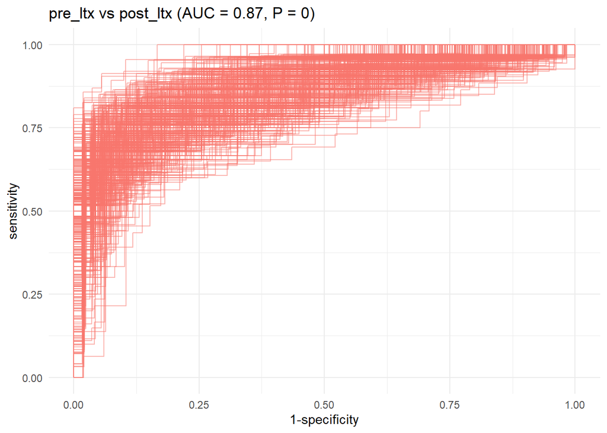

```r
roc_c
```

**post_ltx vs healthy**

```r
group <- c("post_ltx","healthy")
comparison_name <- paste0(group[1], " vs ",group[2])
```

```r
model_name <- paste(comparison_name,level,segment)

# prepare the data
filt_ileum_uni_data <- binomial_prep(ileum_asv_tab,
                                     ileum_taxa_tab,
                                     ileum_metadata,
                                     group, usage="ml_clr")
```

```
Removing 641 ASV(s)
```

```
Removing 104 ASV(s)
```

```r
# fit the model
gbm_model <- gbm_binomial(filt_ileum_uni_data,
                              sample_method = "atypboot",
                              outcome="Group",
                              N=10,
                              reuse=TRUE,
                              file=model_name,
                              Q="Q1")

# ROC curve
roc_c <- roc_curve(gbm_model, group)

# save the results
supplements_models[["models_summ"]][["gbm_model"]][[model_name]] <- gbm_model$model_summary
supplements_models[["roc_cs"]][["gbm_model"]][[model_name]] <- gbm_model$kfold_rocobjs


# see the results
gbm_model$model_summary %>% t()
```

```
                                       [,1]
n.trees                         100.0000000
interaction.depth                 5.0000000
shrinkage                         0.1000000
n.minobsinnode                   20.0000000
auc                               1.0000000
auc_optimism_corrected            0.9250994
auc_optimism_corrected_CIL        0.8522212
auc_optimism_corrected_CIU        0.9818952
accuracy                          1.0000000
accuracy_optimism_corrected       0.8766714
accuracy_optimism_corrected_CIL   0.8050354
accuracy_optimism_corrected_CIU   0.9358974
```

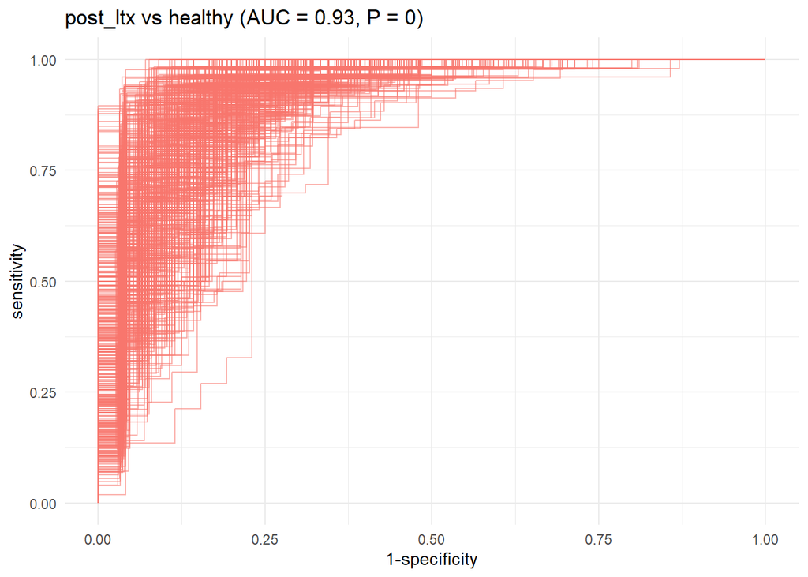

```r
roc_c
```

###### 2.5.2.1.3.2 Genus level

```r
level="genus"
```

Aggregate taxa

```r
genus_data <- aggregate_taxa(ileum_asv_tab,
                             ileum_taxa_tab,
                             taxonomic_level = level)

ileum_genus_tab <- genus_data[[1]]
ileum_genus_taxa_tab <- genus_data[[2]]
```

**pre_ltx vs healthy**

```r
group <- c("pre_ltx","healthy")
comparison_name <- paste0(group[1], " vs ",group[2])
```

```r
model_name <- paste(comparison_name,level,segment)

# prepare the data
filt_ileum_uni_data <- binomial_prep(ileum_genus_tab,
                                     ileum_genus_taxa_tab,
                                     ileum_metadata,
                                     group,
                                     usage="ml_clr")
```

```
Removing 84 ASV(s)
```

```
Removing 10 ASV(s)
```

```r
# fit the model
gbm_model <- gbm_binomial(filt_ileum_uni_data,
                              sample_method = "atypboot",
                              outcome="Group",
                              N=10,
                             reuse=TRUE,
                              file=model_name,
                              Q="Q1")

# ROC curve
roc_c <- roc_curve(gbm_model, group)

# save the results
supplements_models[["models_summ"]][["gbm_model"]][[model_name]] <- gbm_model$model_summary
supplements_models[["roc_cs"]][["gbm_model"]][[model_name]] <- gbm_model$kfold_rocobjs

# see the results
gbm_model$model_summary %>% t()
```

```
                                       [,1]
n.trees                         500.0000000
interaction.depth                 1.0000000
shrinkage                         0.1000000
n.minobsinnode                   20.0000000
auc                               1.0000000
auc_optimism_corrected            0.9727397
auc_optimism_corrected_CIL        0.9275174
auc_optimism_corrected_CIU        1.0000000
accuracy                          1.0000000
accuracy_optimism_corrected       0.9037504
accuracy_optimism_corrected_CIL   0.8155329
accuracy_optimism_corrected_CIU   0.9719540
```

```r
# p-value
print(paste("p_value:",mean(gbm_model$valid_performances$auc_validation<0.5)*2))
```

```
[1] "p_value: 0"
```

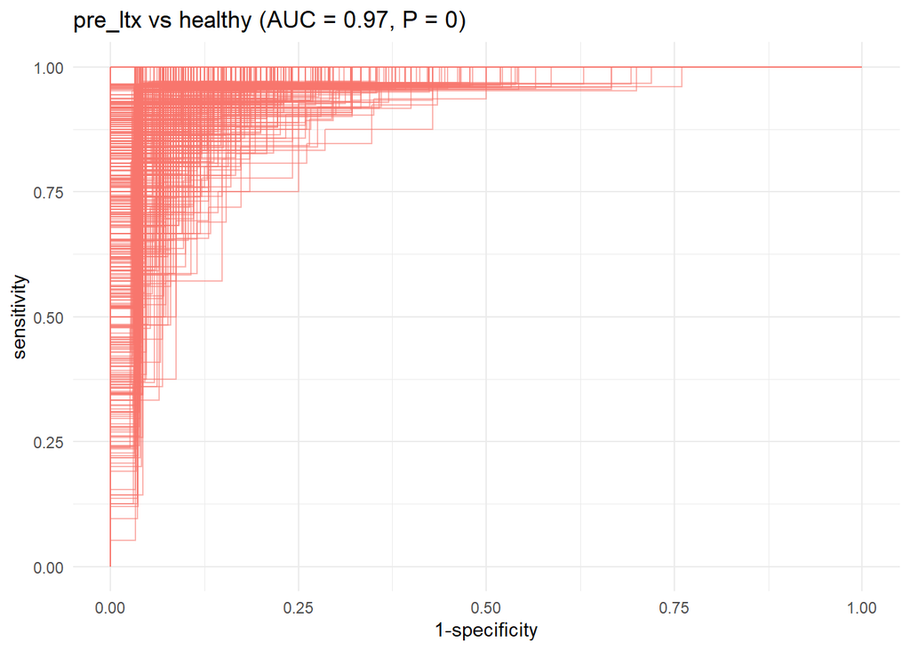

```r
roc_c
```

**pre_ltx vs post_ltx**

```r
group <- c("pre_ltx","post_ltx")
comparison_name <- paste0(group[1], " vs ",group[2])
```

```r
model_name <- paste(comparison_name,level,segment)

# prepare the data
filt_ileum_uni_data <- binomial_prep(ileum_genus_tab,
                                     ileum_genus_taxa_tab,
                                     ileum_metadata,
                                     group,
                                     usage="ml_clr")
```

```
Removing 46 ASV(s)
```

```
Removing 6 ASV(s)
```

```r
# fit the model
gbm_model <- gbm_binomial(filt_ileum_uni_data,
                              sample_method = "atypboot",
                              outcome="Group",
                              N=10,
                              reuse=TRUE,
                              file=model_name,
                              Q="Q1")

# ROC curve
roc_c <- roc_curve(gbm_model, group)

# save the results
supplements_models[["models_summ"]][["gbm_model"]][[model_name]] <- gbm_model$model_summary
supplements_models[["roc_cs"]][["gbm_model"]][[model_name]] <- gbm_model$kfold_rocobjs

# see the results
gbm_model$model_summary %>% t()
```

```
                                       [,1]
n.trees                         100.0000000
interaction.depth                 1.0000000
shrinkage                         0.1000000
n.minobsinnode                   10.0000000
auc                               0.9909938
auc_optimism_corrected            0.8303197
auc_optimism_corrected_CIL        0.7403750
auc_optimism_corrected_CIU        0.9115621
accuracy                          0.9278846
accuracy_optimism_corrected       0.7987144
accuracy_optimism_corrected_CIL   0.7053850
accuracy_optimism_corrected_CIU   0.8767736
```

```r
# p-value
print(paste("p_value:",mean(gbm_model$valid_performances$auc_validation<0.5)*2))
```

```
[1] "p_value: 0"
```

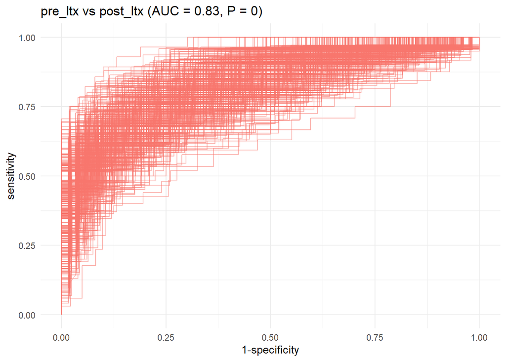

```r
roc_c
```

**post_ltx vs healthy**

```r
group <- c("post_ltx","healthy")
comparison_name <- paste0(group[1], " vs ",group[2])
```

```r
model_name <- paste(comparison_name,level,segment)

# prepare the data
filt_ileum_uni_data <- binomial_prep(ileum_genus_tab,
                                     ileum_genus_taxa_tab,
                                     ileum_metadata,
                                     group,
                                     usage="ml_clr")
```

```
Removing 45 ASV(s)
```

```
Removing 2 ASV(s)
```

```r
# fit the model
gbm_model <- gbm_binomial(filt_ileum_uni_data,
                              sample_method = "atypboot",
                              outcome="Group",
                              N=10,
                              reuse=TRUE,
                              file=model_name,
                              Q="Q1")

# ROC curve
roc_c <- roc_curve(gbm_model, group)

# save the results
supplements_models[["models_summ"]][["gbm_model"]][[model_name]] <- gbm_model$model_summary
supplements_models[["roc_cs"]][["gbm_model"]][[model_name]] <- gbm_model$kfold_rocobjs

# see the results
gbm_model$model_summary %>% t()
```

```
                                       [,1]
n.trees                         200.0000000
interaction.depth                 3.0000000
shrinkage                         0.1000000
n.minobsinnode                   20.0000000
auc                               1.0000000
auc_optimism_corrected            0.9369762
auc_optimism_corrected_CIL        0.8678590
auc_optimism_corrected_CIU        0.9834064
accuracy                          1.0000000
accuracy_optimism_corrected       0.8813001
accuracy_optimism_corrected_CIL   0.8133333
accuracy_optimism_corrected_CIU   0.9448440
```

```r
# p-value
print(paste("p_value:",mean(gbm_model$valid_performances$auc_validation<0.5)*2))
```

```
[1] "p_value: 0"
```

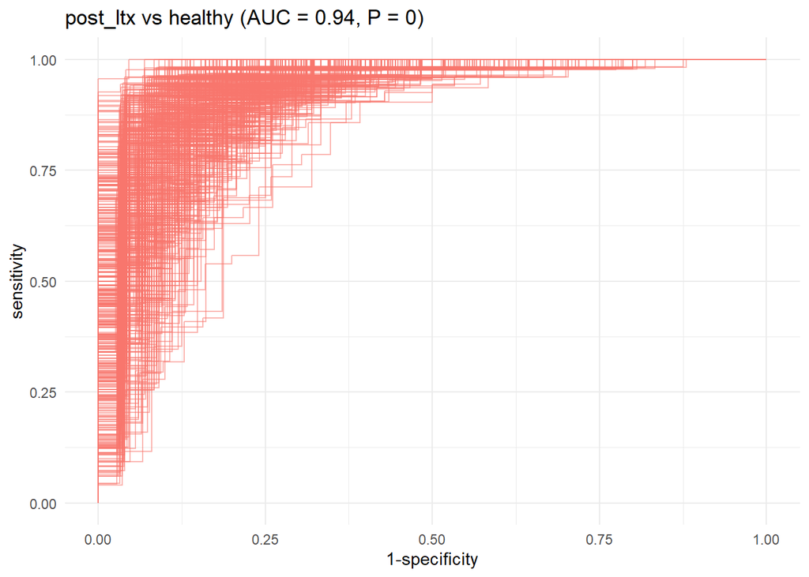

```r
roc_c
```

#### 2.5.2.2 Relative abundances

##### 2.5.2.2.1 Elastic net

###### 2.5.2.2.1.1 ASV level

```r
level="ASV"
```

*pre_ltx vs healthy*

```r
group <- c("pre_ltx","healthy")
comparison_name <- paste0(group[1], " vs ",group[2])
```

```r
model_name <- paste(comparison_name,level,segment)

# prepare the data
filt_ileum_uni_data <- binomial_prep(ileum_asv_tab,
                                     ileum_taxa_tab,
                                     ileum_metadata,
                                     group, usage="ml_ra")
```

```
Removing 1598 ASV(s)
```

```
Removing 146 ASV(s)
```

```r
# fit the model
enet_model <- glmnet_binomial(filt_ileum_uni_data,
                              sample_method = "atypboot",
                              outcome="Group",
                              N=10,
                              reuse=TRUE,
                              file=model_name,
                              Q="Q1")

# ROC curve
roc_c <- roc_curve(enet_model, group)

# save the results
supplements_models[["models_summ"]][["enet_model_ra"]][[model_name]] <- enet_model$model_summary

supplements_models[["roc_cs"]][["enet_model_ra"]][[model_name]] <- enet_model$kfold_rocobjs

# see the results
enet_model$model_summary %>% t()
```

```
                                      [,1]
alpha                           1.00000000
lambda                          0.06282139
auc                             0.99726027
auc_czech                       0.99662162
auc_no                          0.99818841
auc_optimism_corrected          0.92410231
auc_optimism_corrected_CIL      0.83677721
auc_optimism_corrected_CIU      0.97242424
accuracy                        0.93706294
accuracy_czech                         NaN
accuracy_no                     0.93902439
accuracy_optimism_corrected     0.85997837
accuracy_optimism_corrected_CIL 0.77602041
accuracy_optimism_corrected_CIU 0.91766690
```

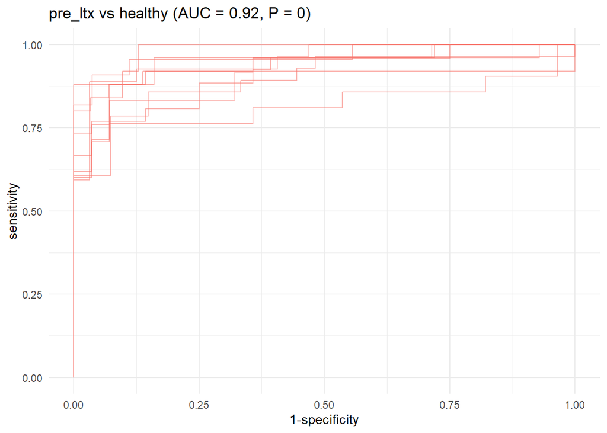

```r
roc_c
```

**pre_ltx vs post_ltx**

```r
group <- c("pre_ltx","post_ltx")
comparison_name <- paste0(group[1], " vs ",group[2])
```

```r
model_name <- paste(comparison_name,level,segment)

# prepare the data
filt_ileum_uni_data <- binomial_prep(ileum_asv_tab,
                                     ileum_taxa_tab,
                                     ileum_metadata,
                                     group, usage="ml_ra")
```

```
Removing 979 ASV(s)
```

```
Removing 68 ASV(s)
```

```r
# fit the model
enet_model <- glmnet_binomial(filt_ileum_uni_data,
                              sample_method = "atypboot",
                              outcome="Group",
                              N=10,
                              reuse=TRUE,
                              file=model_name,
                              Q="Q1")

# ROC curve
roc_c <- roc_curve(enet_model, group)

# save the results
supplements_models[["models_summ"]][["enet_model_ra"]][[model_name]] <- enet_model$model_summary

supplements_models[["roc_cs"]][["enet_model_ra"]][[model_name]] <- enet_model$kfold_rocobjs

# see the results
enet_model$model_summary %>% t()
```

```
                                     [,1]
alpha                           0.0000000
lambda                          3.1074497
auc                             0.9894410
auc_czech                       0.9950980
auc_no                          0.9734300
auc_optimism_corrected          0.7340394
auc_optimism_corrected_CIL      0.6170852
auc_optimism_corrected_CIU      0.8336118
accuracy                        0.7259615
accuracy_czech                        NaN
accuracy_no                     0.5243902
accuracy_optimism_corrected     0.6974512
accuracy_optimism_corrected_CIL 0.5967411
accuracy_optimism_corrected_CIU 0.8050044
```

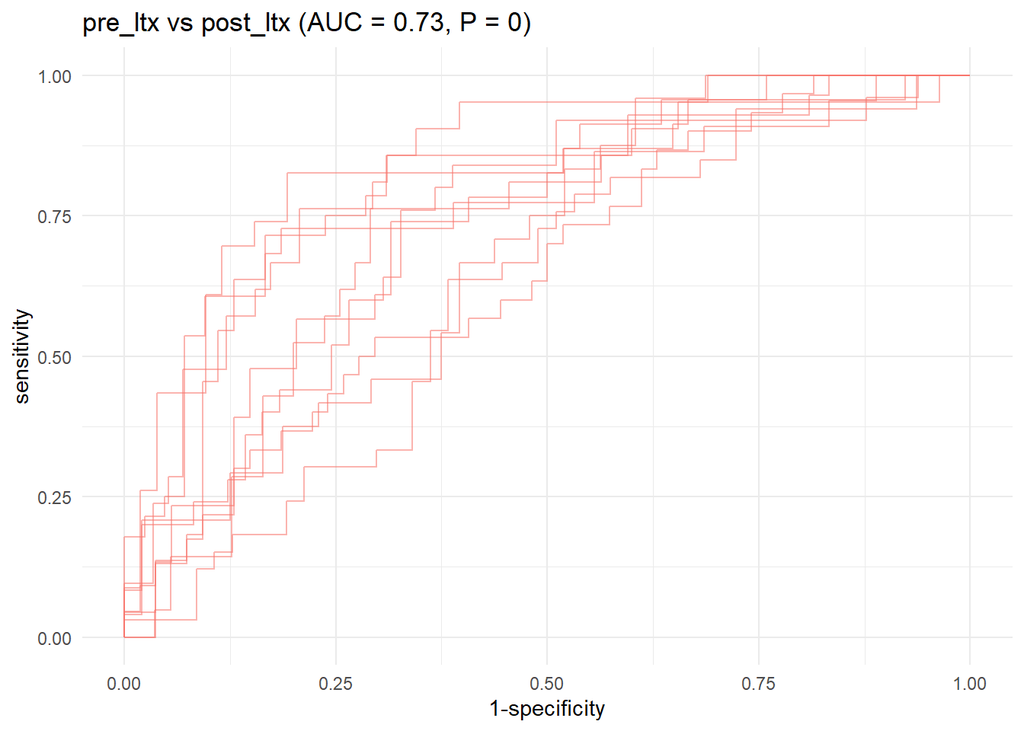

```r
roc_c
```

**post_ltx vs healthy**

```r
group <- c("post_ltx","healthy")
comparison_name <- paste0(group[1], " vs ",group[2])
```

```r
model_name <- paste(comparison_name,level,segment)


# prepare the data
filt_ileum_uni_data <- binomial_prep(ileum_asv_tab,
                                     ileum_taxa_tab,
                                     ileum_metadata,
                                     group, usage="ml_ra")
```

```
Removing 641 ASV(s)
```

```
Removing 104 ASV(s)
```

```r
# fit the model
enet_model <- glmnet_binomial(filt_ileum_uni_data,
                              sample_method = "atypboot",
                              outcome="Group",
                              N=10,
                              reuse=TRUE,
                              file=model_name,
                              Q="Q1")

# ROC curve
roc_c <- roc_curve(enet_model, group)

# save the results
supplements_models[["models_summ"]][["enet_model_ra"]][[model_name]] <- enet_model$model_summary

supplements_models[["roc_cs"]][["enet_model_ra"]][[model_name]] <- enet_model$kfold_rocobjs

# see the results
enet_model$model_summary %>% t()
```

```
                                     [,1]
alpha                           0.2000000
lambda                          0.0941553
auc                             1.0000000
auc_czech                       1.0000000
auc_no                          1.0000000
auc_optimism_corrected          0.8878147
auc_optimism_corrected_CIL      0.8182230
auc_optimism_corrected_CIU      0.9395208
accuracy                        0.9620853
accuracy_czech                        NaN
accuracy_no                     0.9861111
accuracy_optimism_corrected     0.8346693
accuracy_optimism_corrected_CIL 0.7516067
accuracy_optimism_corrected_CIU 0.9093405
```

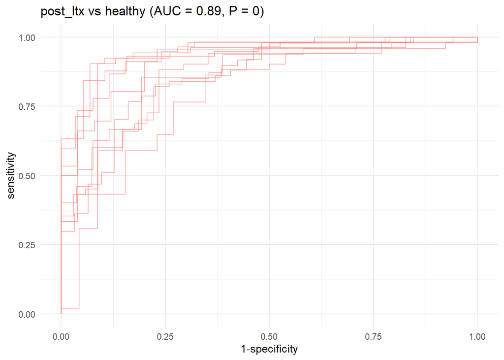

```r
roc_c
```

###### 2.5.2.2.1.2 Genus level

```r
level="genus"
```

Aggregate taxa

```r
genus_data <- aggregate_taxa(ileum_asv_tab,
                             ileum_taxa_tab,
                             taxonomic_level = level)

ileum_genus_tab <- genus_data[[1]]
ileum_genus_taxa_tab <- genus_data[[2]]
```

**pre_ltx vs healthy**

```r
group <- c("pre_ltx","healthy")
comparison_name <- paste0(group[1], " vs ",group[2])
```

```r
model_name <- paste(comparison_name,level,segment)

# prepare the data
filt_ileum_uni_data <- binomial_prep(ileum_genus_tab,
                                     ileum_genus_taxa_tab,
                                     ileum_metadata,
                                     group,
                                     usage="ml_ra")
```

```
Removing 84 ASV(s)
```

```
Removing 10 ASV(s)
```

```r
# fit the model
enet_model <- glmnet_binomial(filt_ileum_uni_data,
                              sample_method = "atypboot",
                              outcome="Group",
                              N=10,
                              reuse=TRUE,
                              file=model_name,
                              Q="Q1")

# ROC curve
roc_c <- roc_curve(enet_model, group)

# save the results
supplements_models[["models_summ"]][["enet_model_ra"]][[model_name]] <- enet_model$model_summary

supplements_models[["roc_cs"]][["enet_model_ra"]][[model_name]] <- enet_model$kfold_rocobjs

# see the results
enet_model$model_summary %>% t()
```

```
                                     [,1]
alpha                           0.2000000
lambda                          0.1357028
auc                             0.9982387
auc_czech                       0.9954955
auc_no                          1.0000000
auc_optimism_corrected          0.9386177
auc_optimism_corrected_CIL      0.8965000
auc_optimism_corrected_CIU      0.9793945
accuracy                        0.9860140
accuracy_czech                        NaN
accuracy_no                     1.0000000
accuracy_optimism_corrected     0.8663045
accuracy_optimism_corrected_CIL 0.8016509
accuracy_optimism_corrected_CIU 0.9358844
```

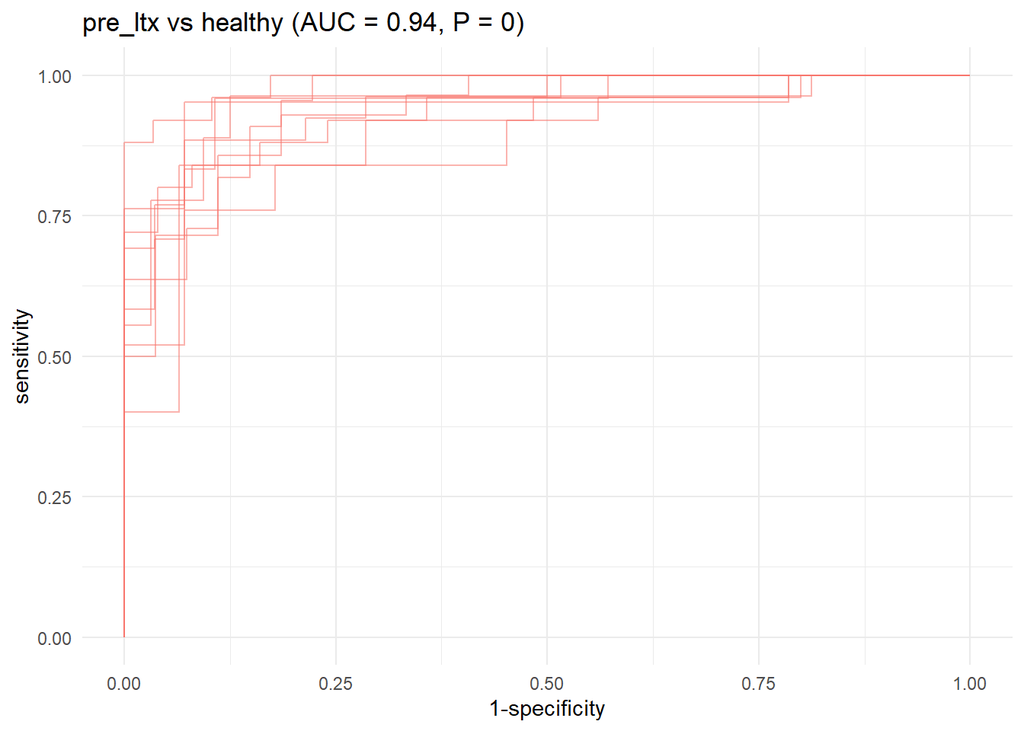

```r
roc_c
```

**pre_ltx vs post_ltx**

```r
group <- c("pre_ltx","post_ltx")
comparison_name <- paste0(group[1], " vs ",group[2])
```

```r
model_name <- paste(comparison_name,level,segment)


# prepare the data
filt_ileum_uni_data <- binomial_prep(ileum_genus_tab,
                                     ileum_genus_taxa_tab,
                                     ileum_metadata,
                                     group,
                                     usage="ml_ra")
```

```
Removing 46 ASV(s)
```

```
Removing 6 ASV(s)
```

```r
# fit the model
enet_model <- glmnet_binomial(filt_ileum_uni_data,
                              sample_method = "atypboot",
                              outcome="Group",
                              N=10,
                              reuse=TRUE,
                              file=model_name,
                              Q="Q1")

# ROC curve
roc_c <- roc_curve(enet_model, group)

# save the results
supplements_models[["models_summ"]][["enet_model_ra"]][[model_name]] <- enet_model$model_summary

supplements_models[["roc_cs"]][["enet_model_ra"]][[model_name]] <- enet_model$kfold_rocobjs

# see the results
enet_model$model_summary %>% t()
```

```
                                      [,1]
alpha                           0.40000000
lambda                          0.08652139
auc                             0.94720497
auc_czech                       0.95751634
auc_no                          0.88828502
auc_optimism_corrected          0.73722094
auc_optimism_corrected_CIL      0.65355232
auc_optimism_corrected_CIU      0.81212375
accuracy                        0.82211538
accuracy_czech                         NaN
accuracy_no                     0.73170732
accuracy_optimism_corrected     0.71869940
accuracy_optimism_corrected_CIL 0.61986111
accuracy_optimism_corrected_CIU 0.79628473
```

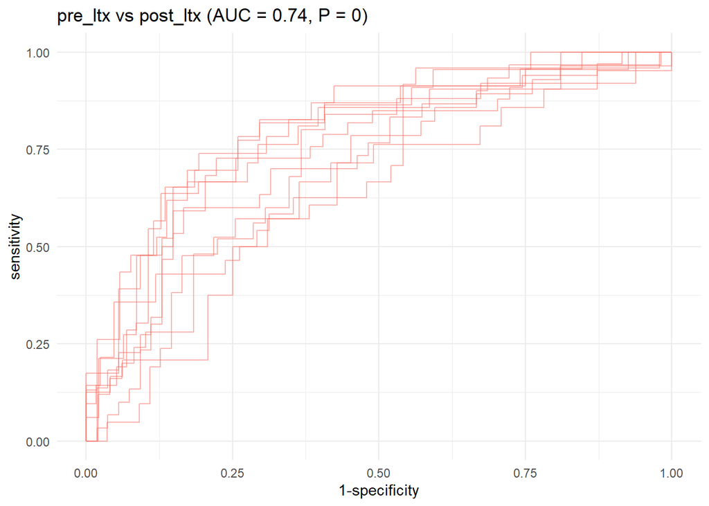

```r
roc_c
```

**post_ltx vs healthy**

```r
group <- c("post_ltx","healthy")
comparison_name <- paste0(group[1], " vs ",group[2])
```

```r
model_name <- paste(comparison_name,level,segment)

# prepare the data
filt_ileum_uni_data <- binomial_prep(ileum_genus_tab,
                                     ileum_genus_taxa_tab,
                                     ileum_metadata,
                                     group,
                                     usage="ml_ra")
```

```
Removing 45 ASV(s)
```

```
Removing 2 ASV(s)
```

```r
# fit the model
enet_model <- glmnet_binomial(filt_ileum_uni_data,
                              sample_method = "atypboot",
                              outcome="Group",
                              N=10,
                              reuse=TRUE,
                              file=model_name,
                              Q="Q1")

# ROC curve
roc_c <- roc_curve(enet_model, group)

# save the results
supplements_models[["models_summ"]][["enet_model_ra"]][[model_name]] <- enet_model$model_summary

supplements_models[["roc_cs"]][["enet_model_ra"]][[model_name]] <- enet_model$kfold_rocobjs

# see the results
enet_model$model_summary %>% t()
```

```
                                     [,1]
alpha                           0.2000000
lambda                          0.1352860
auc                             0.9857058
auc_czech                       0.9809221
auc_no                          0.9915123
auc_optimism_corrected          0.8571252
auc_optimism_corrected_CIL      0.8014650
auc_optimism_corrected_CIU      0.8939396
accuracy                        0.9099526
accuracy_czech                        NaN
accuracy_no                     0.9583333
accuracy_optimism_corrected     0.7924925
accuracy_optimism_corrected_CIL 0.7205995
accuracy_optimism_corrected_CIU 0.8558642
```

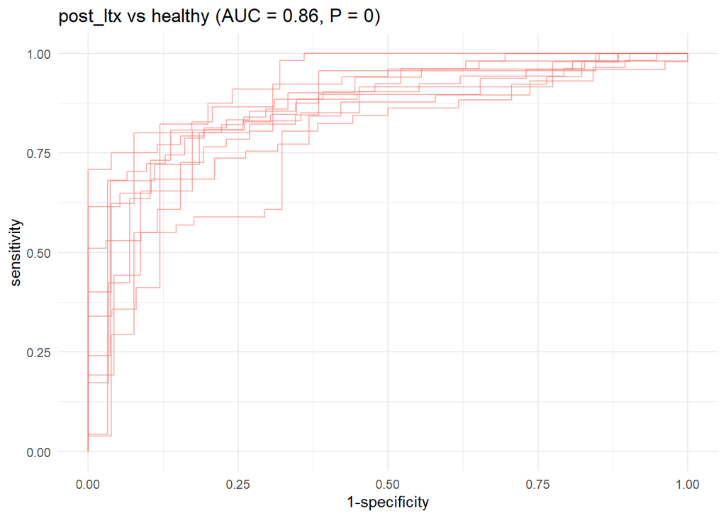

```r
roc_c
```

##### 2.5.2.2.2 kNN

###### 2.5.2.2.2.1 ASV level

```r
level="ASV"
```

*pre_ltx vs healthy*

```r
group <- c("pre_ltx","healthy")
comparison_name <- paste0(group[1], " vs ",group[2])
```

```r
model_name <- paste(comparison_name,level,segment)

# prepare the data
filt_ileum_uni_data <- binomial_prep(ileum_asv_tab,
                                     ileum_taxa_tab,
                                     ileum_metadata,
                                     group, usage="ml_ra")
```

```
Removing 1598 ASV(s)
```

```
Removing 146 ASV(s)
```

```r
# fit the model
knn_model <- knn_binomial(filt_ileum_uni_data,
                              sample_method = "atypboot",
                              outcome="Group",
                              N=10,
                              reuse=TRUE,
                              file=model_name,
                              Q="Q1")

# ROC curve
roc_c <- roc_curve(knn_model, group)

# save the results
supplements_models[["models_summ"]][["knn_model_ra"]][[model_name]] <- knn_model$model_summary

supplements_models[["roc_cs"]][["knn_model_ra"]][[model_name]] <- knn_model$kfold_rocobjs

# see the results
knn_model$model_summary %>% t()
```

```
                                      [,1]
k                               10.0000000
auc                              0.9155577
auc_optimism_corrected           0.8288216
auc_optimism_corrected_CIL       0.6990440
auc_optimism_corrected_CIU       0.9324125
accuracy                         0.6993007
accuracy_optimism_corrected      0.6665810
accuracy_optimism_corrected_CIL  0.5590566
accuracy_optimism_corrected_CIU  0.7549259
```

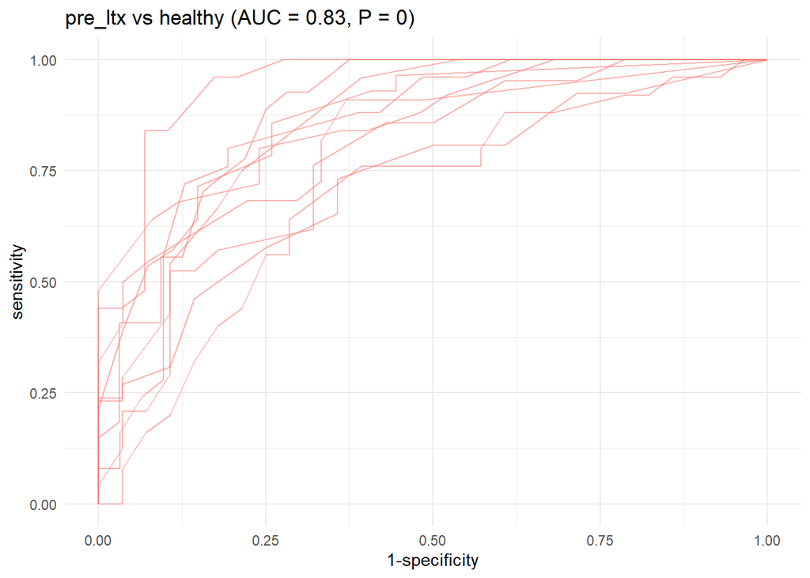

```r
roc_c
```

**pre_ltx vs post_ltx**

```r
group <- c("pre_ltx","post_ltx")
comparison_name <- paste0(group[1], " vs ",group[2])
```

```r
model_name <- paste(comparison_name,level,segment)

# prepare the data
filt_ileum_uni_data <- binomial_prep(ileum_asv_tab,
                                     ileum_taxa_tab,
                                     ileum_metadata,
                                     group, usage="ml_ra")
```

```
Removing 979 ASV(s)
```

```
Removing 68 ASV(s)
```

```r
# fit the model
knn_model <- knn_binomial(filt_ileum_uni_data,
                              sample_method = "atypboot",
                              outcome="Group",
                              N=10,
                              reuse=TRUE,
                              file=model_name,
                              Q="Q1")

# ROC curve
roc_c <- roc_curve(knn_model, group)

# save the results
supplements_models[["models_summ"]][["knn_model_ra"]][[model_name]] <- knn_model$model_summary

supplements_models[["roc_cs"]][["knn_model_ra"]][[model_name]] <- knn_model$kfold_rocobjs

# see the results
knn_model$model_summary %>% t()
```

```
                                      [,1]
k                               20.0000000
auc                              0.8137164
auc_optimism_corrected           0.6656270
auc_optimism_corrected_CIL       0.5828798
auc_optimism_corrected_CIU       0.7357973
accuracy                         0.6778846
accuracy_optimism_corrected      0.6814455
accuracy_optimism_corrected_CIL  0.6193304
accuracy_optimism_corrected_CIU  0.7416264
```

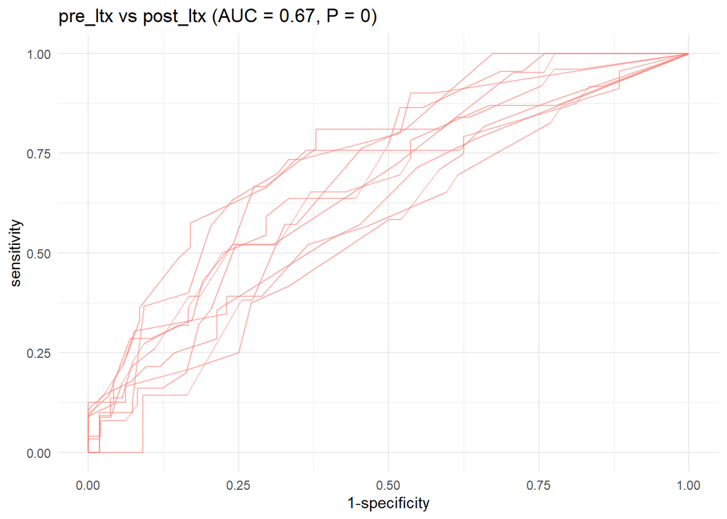

```r
roc_c
```

**post_ltx vs healthy**

```r
group <- c("post_ltx","healthy")
comparison_name <- paste0(group[1], " vs ",group[2])
```

```r
model_name <- paste(comparison_name,level,segment)

# prepare the data
filt_ileum_uni_data <- binomial_prep(ileum_asv_tab,
                                     ileum_taxa_tab,
                                     ileum_metadata,
                                     group, usage="ml_ra")
```

```
Removing 641 ASV(s)
```

```
Removing 104 ASV(s)
```

```r
# fit the model
knn_model <- knn_binomial(filt_ileum_uni_data,
                              sample_method = "atypboot",
                              outcome="Group",
                              N=10,
                              reuse=TRUE,
                              file=model_name,
                              Q="Q1")

# ROC curve
roc_c <- roc_curve(knn_model, group)

# save the results
supplements_models[["models_summ"]][["knn_model_ra"]][[model_name]] <- knn_model$model_summary

supplements_models[["roc_cs"]][["knn_model_ra"]][[model_name]] <- knn_model$kfold_rocobjs

# see the results
knn_model$model_summary %>% t()
```

```
                                      [,1]
k                               15.0000000
auc                              0.8773576
auc_optimism_corrected           0.8241731
auc_optimism_corrected_CIL       0.7426389
auc_optimism_corrected_CIU       0.9093236
accuracy                         0.8578199
accuracy_optimism_corrected      0.7672256
accuracy_optimism_corrected_CIL  0.6851333
accuracy_optimism_corrected_CIU  0.8682099
```

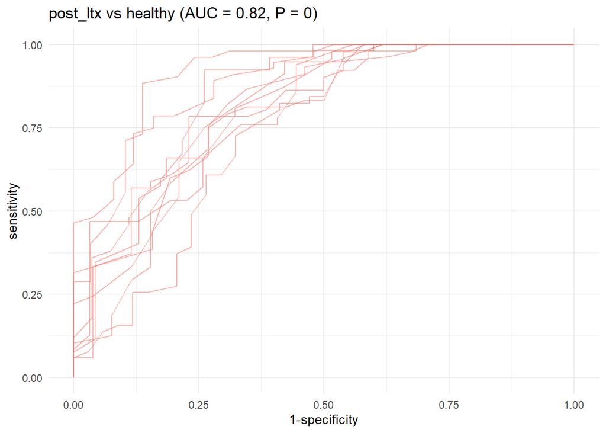

```r
roc_c
```

###### 2.5.2.2.2.2 Genus level

```r
level="genus"
```

Aggregate taxa

```r
genus_data <- aggregate_taxa(ileum_asv_tab,
                             ileum_taxa_tab,
                             taxonomic_level = level)

ileum_genus_tab <- genus_data[[1]]
ileum_genus_taxa_tab <- genus_data[[2]]
```

**pre_ltx vs healthy**

```r
group <- c("pre_ltx","healthy")
comparison_name <- paste0(group[1], " vs ",group[2])
```

```r
model_name <- paste(comparison_name,level,segment)

# prepare the data
filt_ileum_uni_data <- binomial_prep(ileum_genus_tab,
                                     ileum_genus_taxa_tab,
                                     ileum_metadata,
                                     group,
                                     usage="ml_ra")
```

```
Removing 84 ASV(s)
```

```
Removing 10 ASV(s)
```

```r
# fit the model
knn_model <- knn_binomial(filt_ileum_uni_data,
                              sample_method = "atypboot",
                              outcome="Group",
                              N=10,
                              reuse=TRUE,
                              file=model_name,
                              Q="Q1")

# ROC curve
roc_c <- roc_curve(knn_model, group)

# save the results
supplements_models[["models_summ"]][["knn_model_ra"]][[model_name]] <- knn_model$model_summary

supplements_models[["roc_cs"]][["knn_model_ra"]][[model_name]] <- knn_model$kfold_rocobjs

# see the results
knn_model$model_summary %>% t()
```

```
                                      [,1]
k                               11.0000000
auc                              0.9076321
auc_optimism_corrected           0.8187868
auc_optimism_corrected_CIL       0.7649740
auc_optimism_corrected_CIU       0.8737386
accuracy                         0.7622378
accuracy_optimism_corrected      0.7045763
accuracy_optimism_corrected_CIL  0.6121154
accuracy_optimism_corrected_CIU  0.7918367
```

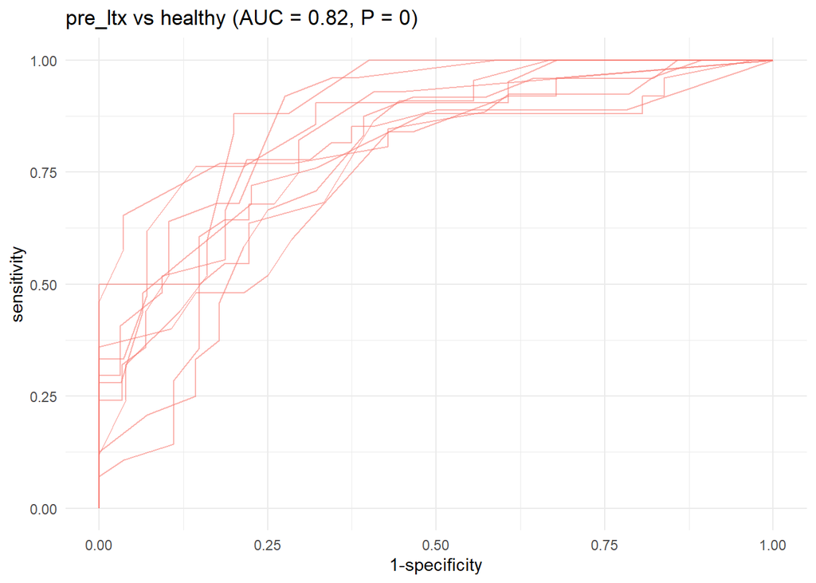

```r
roc_c
```

**pre_ltx vs post_ltx**

```r
group <- c("pre_ltx","post_ltx")
comparison_name <- paste0(group[1], " vs ",group[2])
```

```r
model_name <- paste(comparison_name,level,segment)

# prepare the data
filt_ileum_uni_data <- binomial_prep(ileum_genus_tab,
                                     ileum_genus_taxa_tab,
                                     ileum_metadata,
                                     group,
                                     usage="ml_ra")
```

```
Removing 46 ASV(s)
```

```
Removing 6 ASV(s)
```

```r
# fit the model
knn_model <- knn_binomial(filt_ileum_uni_data,
                              sample_method = "atypboot",
                              outcome="Group",
                              N=10,
                              reuse=TRUE,
                              file=model_name,
                              Q="Q1")

# ROC curve
roc_c <- roc_curve(knn_model, group)

# save the results
supplements_models[["models_summ"]][["knn_model_ra"]][[model_name]] <- knn_model$model_summary

supplements_models[["roc_cs"]][["knn_model_ra"]][[model_name]] <- knn_model$kfold_rocobjs

# see the results
knn_model$model_summary %>% t()
```

```
                                      [,1]
k                               19.0000000
auc                              0.8088509
auc_optimism_corrected           0.7182619
auc_optimism_corrected_CIL       0.6604457
auc_optimism_corrected_CIU       0.7917652
accuracy                         0.7403846
accuracy_optimism_corrected      0.7189495
accuracy_optimism_corrected_CIL  0.6446429
accuracy_optimism_corrected_CIU  0.7566076
```

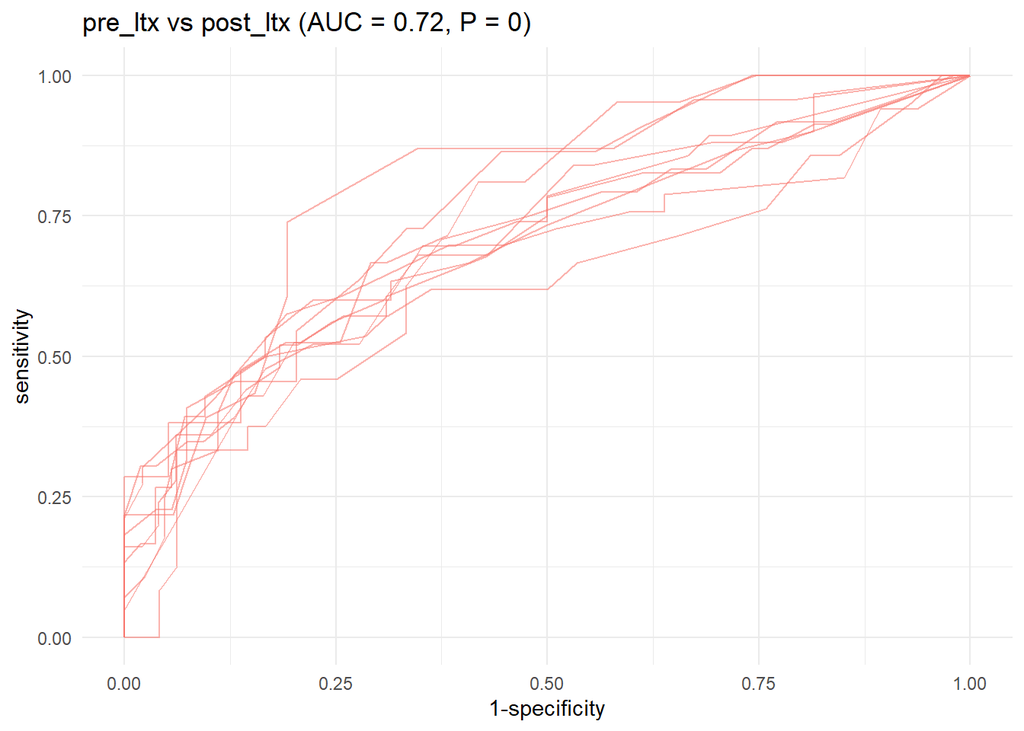

```r
roc_c
```

**post_ltx vs healthy**

```r
group <- c("post_ltx","healthy")
comparison_name <- paste0(group[1], " vs ",group[2])
```

```r
model_name <- paste(comparison_name,level,segment)

# prepare the data
filt_ileum_uni_data <- binomial_prep(ileum_genus_tab,
                                     ileum_genus_taxa_tab,
                                     ileum_metadata,
                                     group,
                                     usage="ml_ra")
```

```
Removing 45 ASV(s)
```

```
Removing 2 ASV(s)
```

```r
# fit the model
knn_model <- knn_binomial(filt_ileum_uni_data,
                              sample_method = "atypboot",
                              outcome="Group",
                              N=10,
                              reuse=TRUE,
                              file=model_name,
                              Q="Q1")

# ROC curve
roc_c <- roc_curve(knn_model, group)

# save the results
supplements_models[["models_summ"]][["knn_model_ra"]][[model_name]] <- knn_model$model_summary

supplements_models[["roc_cs"]][["knn_model_ra"]][[model_name]] <- knn_model$kfold_rocobjs

# see the results
knn_model$model_summary %>% t()
```

```
                                      [,1]
k                               21.0000000
auc                              0.8874330
auc_optimism_corrected           0.8009876
auc_optimism_corrected_CIL       0.7335368
auc_optimism_corrected_CIU       0.8864556
accuracy                         0.8151659
accuracy_optimism_corrected      0.7465345
accuracy_optimism_corrected_CIL  0.6166738
accuracy_optimism_corrected_CIU  0.8089339
```

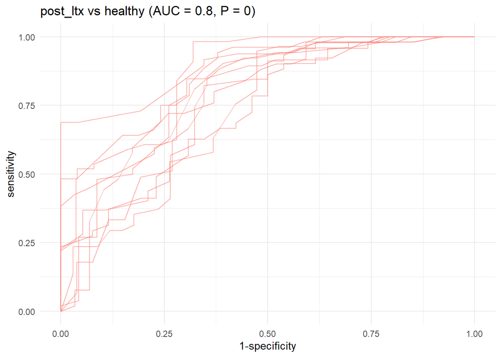

```r
roc_c
```

##### 2.5.2.2.3 RF

###### 2.5.2.2.3.1 ASV level

```r
level="ASV"
```

*pre_ltx vs healthy*

```r
group <- c("pre_ltx","healthy")
comparison_name <- paste0(group[1], " vs ",group[2])
```

```r
model_name <- paste(comparison_name,level,segment)

# prepare the data
filt_ileum_uni_data <- binomial_prep(ileum_asv_tab,
                                     ileum_taxa_tab,
                                     ileum_metadata,
                                     group, usage="ml_ra")
```

```
Removing 1598 ASV(s)
```

```
Removing 146 ASV(s)
```

```r
# fit the model
rf_model <- rf_binomial(filt_ileum_uni_data,
                              sample_method = "atypboot",
                              outcome="Group",
                              N=10,
                              reuse=TRUE,
                              file=model_name,
                              Q="Q1")

# ROC curve
roc_c <- roc_curve(rf_model, group)

# save the results
supplements_models[["models_summ"]][["rf_model_ra"]][[model_name]] <- rf_model$model_summary

supplements_models[["roc_cs"]][["rf_model_ra"]][[model_name]] <- rf_model$kfold_rocobjs

# see the results
rf_model$model_summary %>% t()
```

```
                                [,1]
mtry                            "71"
splitrule                       "gini"
min.node.size                   "5"
auc                             "1"
auc_optimism_corrected          "0.9749018"
auc_optimism_corrected_CIL      "0.9501443"
auc_optimism_corrected_CIU      "0.9929425"
accuracy                        "1"
accuracy_optimism_corrected     "0.8954299"
accuracy_optimism_corrected_CIL "0.8438571"
accuracy_optimism_corrected_CIU "0.930791"
```

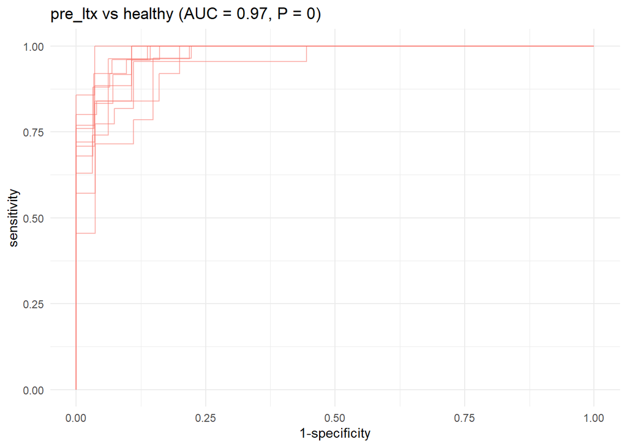

```r
roc_c
```

**pre_ltx vs post_ltx**

```r
group <- c("pre_ltx","post_ltx")
comparison_name <- paste0(group[1], " vs ",group[2])
```

```r
model_name <- paste(comparison_name,level,segment)

# prepare the data
filt_ileum_uni_data <- binomial_prep(ileum_asv_tab,
                                     ileum_taxa_tab,
                                     ileum_metadata,
                                     group, usage="ml_ra")
```

```
Removing 979 ASV(s)
```

```
Removing 68 ASV(s)
```

```r
# fit the model
rf_model <- rf_binomial(filt_ileum_uni_data,
                              sample_method = "atypboot",
                              outcome="Group",
                              N=10,
                              reuse=TRUE,
                              file=model_name,
                              Q="Q1")

# ROC curve
roc_c <- roc_curve(rf_model, group)

# save the results
supplements_models[["models_summ"]][["rf_model_ra"]][[model_name]] <- rf_model$model_summary

supplements_models[["roc_cs"]][["rf_model_ra"]][[model_name]] <- rf_model$kfold_rocobjs


# see the results
rf_model$model_summary %>% t()
```

```
                                [,1]
mtry                            "31"
splitrule                       "gini"
min.node.size                   "5"
auc                             "1"
auc_optimism_corrected          "0.901005"
auc_optimism_corrected_CIL      "0.8504941"
auc_optimism_corrected_CIU      "0.9534551"
accuracy                        "1"
accuracy_optimism_corrected     "0.8441077"
accuracy_optimism_corrected_CIL "0.785"
accuracy_optimism_corrected_CIU "0.8924805"
```

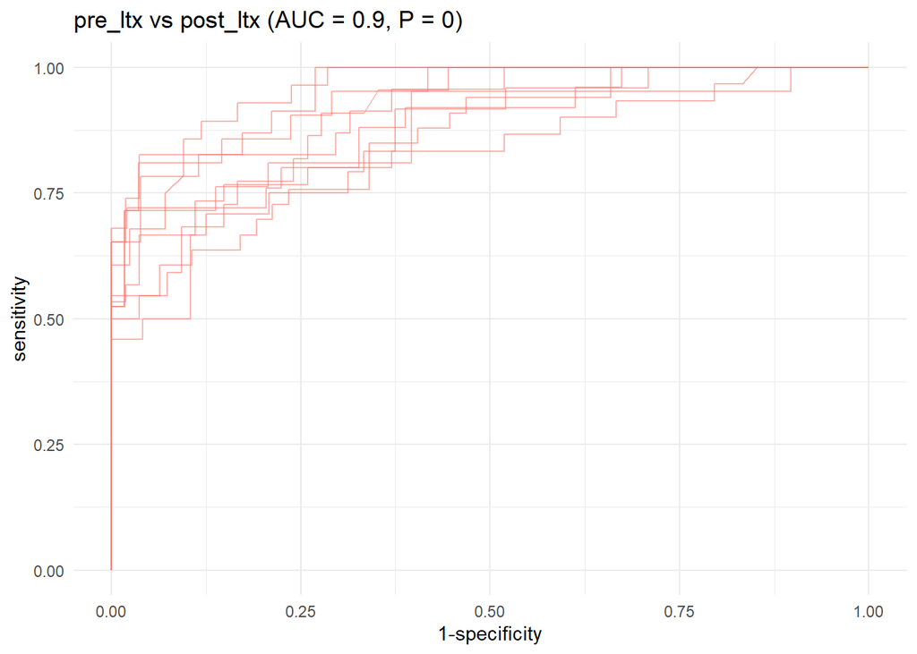

```r
roc_c
```

**post_ltx vs healthy**

```r
group <- c("post_ltx","healthy")
comparison_name <- paste0(group[1], " vs ",group[2])
```

```r
model_name <- paste(comparison_name,level,segment)

# prepare the data
filt_ileum_uni_data <- binomial_prep(ileum_asv_tab,
                                     ileum_taxa_tab,
                                     ileum_metadata,
                                     group, usage="ml_ra")
```

```
Removing 641 ASV(s)
```

```
Removing 104 ASV(s)
```

```r
# fit the model
rf_model <- rf_binomial(filt_ileum_uni_data,
                              sample_method = "atypboot",
                              outcome="Group",
                              N=10,
                              reuse=TRUE,
                              file=model_name,
                              Q="Q1")

# ROC curve
roc_c <- roc_curve(rf_model, group)

# save the results
supplements_models[["models_summ"]][["rf_model_ra"]][[model_name]] <- rf_model$model_summary

supplements_models[["roc_cs"]][["rf_model_ra"]][[model_name]] <- rf_model$kfold_rocobjs


# see the results
rf_model$model_summary %>% t()
```

```
                                [,1]
mtry                            "17"
splitrule                       "gini"
min.node.size                   "5"
auc                             "1"
auc_optimism_corrected          "0.9248253"
auc_optimism_corrected_CIL      "0.8775136"
auc_optimism_corrected_CIU      "0.9641348"
accuracy                        "1"
accuracy_optimism_corrected     "0.875495"
accuracy_optimism_corrected_CIL "0.8132086"
accuracy_optimism_corrected_CIU "0.9172763"
```

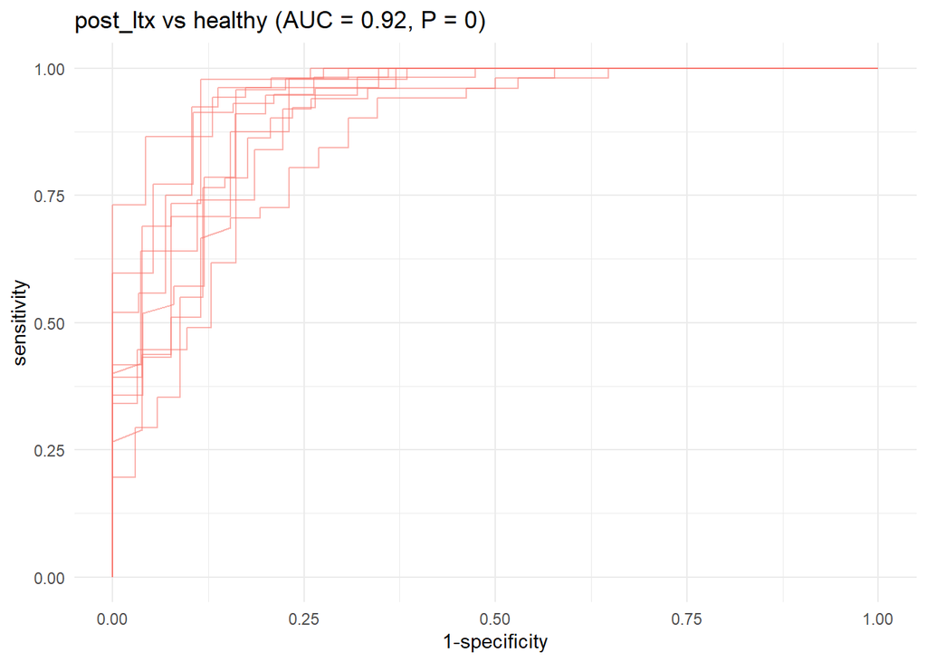

```r
roc_c
```

###### 2.5.2.2.3.2 Genus level

```r
level="genus"
```

Aggregate taxa

```r
genus_data <- aggregate_taxa(ileum_asv_tab,
                             ileum_taxa_tab,
                             taxonomic_level = level)

ileum_genus_tab <- genus_data[[1]]
ileum_genus_taxa_tab <- genus_data[[2]]
```

**pre_ltx vs healthy**

```r
group <- c("pre_ltx","healthy")
comparison_name <- paste0(group[1], " vs ",group[2])
```

```r
model_name <- paste(comparison_name,level,segment)

# prepare the data
filt_ileum_uni_data <- binomial_prep(ileum_genus_tab,
                                     ileum_genus_taxa_tab,
                                     ileum_metadata,
                                     group,
                                     usage="ml_ra")
```

```
Removing 84 ASV(s)
```

```
Removing 10 ASV(s)
```

```r
# fit the model
rf_model <- rf_binomial(filt_ileum_uni_data,
                              sample_method = "atypboot",
                              outcome="Group",
                              N=10,
                              reuse=TRUE,
                              file=model_name,
                              Q="Q1")

# ROC curve
roc_c <- roc_curve(rf_model, group)

# save the results
supplements_models[["models_summ"]][["rf_model_ra"]][[model_name]] <- rf_model$model_summary

supplements_models[["roc_cs"]][["rf_model_ra"]][[model_name]] <- rf_model$kfold_rocobjs


# see the results
rf_model$model_summary %>% t()
```

```
                                [,1]
mtry                            "17"
splitrule                       "gini"
min.node.size                   "5"
auc                             "1"
auc_optimism_corrected          "0.9665056"
auc_optimism_corrected_CIL      "0.9449662"
auc_optimism_corrected_CIU      "0.9863349"
accuracy                        "1"
accuracy_optimism_corrected     "0.902696"
accuracy_optimism_corrected_CIL "0.8441384"
accuracy_optimism_corrected_CIU "0.9399633"
```

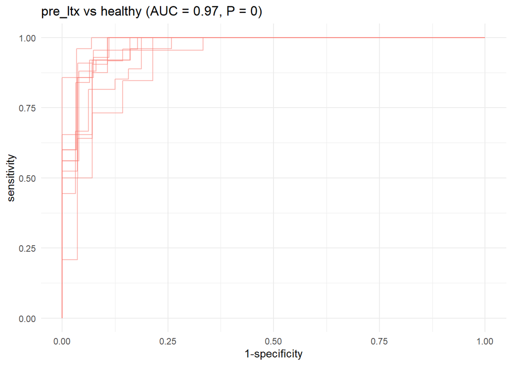

```r
roc_c
```

**pre_ltx vs post_ltx**

```r
group <- c("pre_ltx","post_ltx")
comparison_name <- paste0(group[1], " vs ",group[2])
```

```r
model_name <- paste(comparison_name,level,segment)

# prepare the data
filt_ileum_uni_data <- binomial_prep(ileum_genus_tab,
                                     ileum_genus_taxa_tab,
                                     ileum_metadata,
                                     group,
                                     usage="ml_ra")
```

```
Removing 46 ASV(s)
```

```
Removing 6 ASV(s)
```

```r
# fit the model
rf_model <- rf_binomial(filt_ileum_uni_data,
                              sample_method = "atypboot",
                              outcome="Group",
                              N=10,
                              reuse=TRUE,
                              file=model_name,
                              Q="Q1")

# ROC curve
roc_c <- roc_curve(rf_model, group)

# save the results
supplements_models[["models_summ"]][["rf_model_ra"]][[model_name]] <- rf_model$model_summary

supplements_models[["roc_cs"]][["rf_model_ra"]][[model_name]] <- rf_model$kfold_rocobjs


# see the results
rf_model$model_summary %>% t()
```

```
                                [,1]
mtry                            "85"
splitrule                       "gini"
min.node.size                   "5"
auc                             "1"
auc_optimism_corrected          "0.8604571"
auc_optimism_corrected_CIL      "0.824759"
auc_optimism_corrected_CIU      "0.9035517"
accuracy                        "1"
accuracy_optimism_corrected     "0.8070124"
accuracy_optimism_corrected_CIL "0.758049"
accuracy_optimism_corrected_CIU "0.8571429"
```

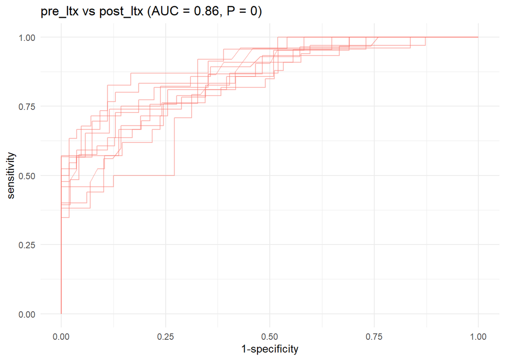

```r
roc_c
```

**post_ltx vs healthy**

```r
group <- c("post_ltx","healthy")
comparison_name <- paste0(group[1], " vs ",group[2])
```

```r
model_name <- paste(comparison_name,level,segment)

# prepare the data
filt_ileum_uni_data <- binomial_prep(ileum_genus_tab,
                                     ileum_genus_taxa_tab,
                                     ileum_metadata,
                                     group,
                                     usage="ml_ra")
```

```
Removing 45 ASV(s)
```

```
Removing 2 ASV(s)
```

```r
# fit the model
rf_model <- rf_binomial(filt_ileum_uni_data,
                              sample_method = "atypboot",
                              outcome="Group",
                              N=10,
                              reuse=TRUE,
                              file=model_name,
                              Q="Q1")

# ROC curve
roc_c <- roc_curve(rf_model, group)

# save the results
supplements_models[["models_summ"]][["rf_model_ra"]][[model_name]] <- rf_model$model_summary

supplements_models[["roc_cs"]][["rf_model_ra"]][[model_name]] <- rf_model$kfold_rocobjs


# see the results
rf_model$model_summary %>% t()
```

```
                                [,1]
mtry                            "31"
splitrule                       "gini"
min.node.size                   "5"
auc                             "1"
auc_optimism_corrected          "0.9158303"
auc_optimism_corrected_CIL      "0.8472241"
auc_optimism_corrected_CIU      "0.9820129"
accuracy                        "1"
accuracy_optimism_corrected     "0.8678365"
accuracy_optimism_corrected_CIL "0.8040909"
accuracy_optimism_corrected_CIU "0.9498863"
```

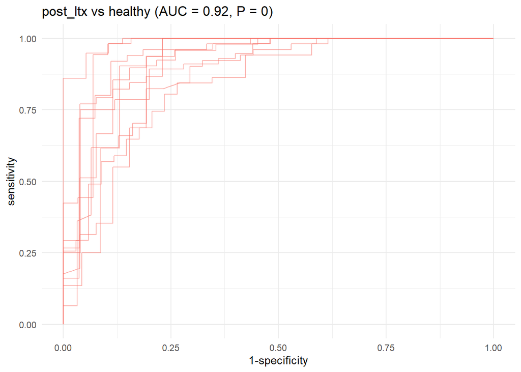

```r
roc_c
```

##### 2.5.2.2.4 Gradient boosting

###### 2.5.2.2.4.1 ASV level

```r
level="ASV"
```

*pre_ltx vs healthy*

```r
group <- c("pre_ltx","healthy")
comparison_name <- paste0(group[1], " vs ",group[2])
```

```r
model_name <- paste(comparison_name,level,segment)

# prepare the data
filt_ileum_uni_data <- binomial_prep(ileum_asv_tab,
                                     ileum_taxa_tab,
                                     ileum_metadata,
                                     group, usage="ml_ra")
```

```
Removing 1598 ASV(s)
```

```
Removing 146 ASV(s)
```

```r
# fit the model
gbm_model <- gbm_binomial(filt_ileum_uni_data,
                              sample_method = "atypboot",
                              outcome="Group",
                              N=10,
                              reuse=TRUE,
                              file=model_name,
                              Q="Q1")

# ROC curve
roc_c <- roc_curve(gbm_model, group)

# save the results
supplements_models[["models_summ"]][["gbm_model_ra"]][[model_name]] <- gbm_model$model_summary

supplements_models[["roc_cs"]][["gbm_model_ra"]][[model_name]] <- gbm_model$kfold_rocobjs

# see the results
gbm_model$model_summary %>% t()
```

```
                                       [,1]
n.trees                         500.0000000
interaction.depth                 3.0000000
shrinkage                         0.1000000
n.minobsinnode                   10.0000000
auc                               1.0000000
auc_optimism_corrected            0.9694065
auc_optimism_corrected_CIL        0.9465650
auc_optimism_corrected_CIU        0.9947741
accuracy                          1.0000000
accuracy_optimism_corrected       0.9138621
accuracy_optimism_corrected_CIL   0.8255102
accuracy_optimism_corrected_CIU   0.9639881
```

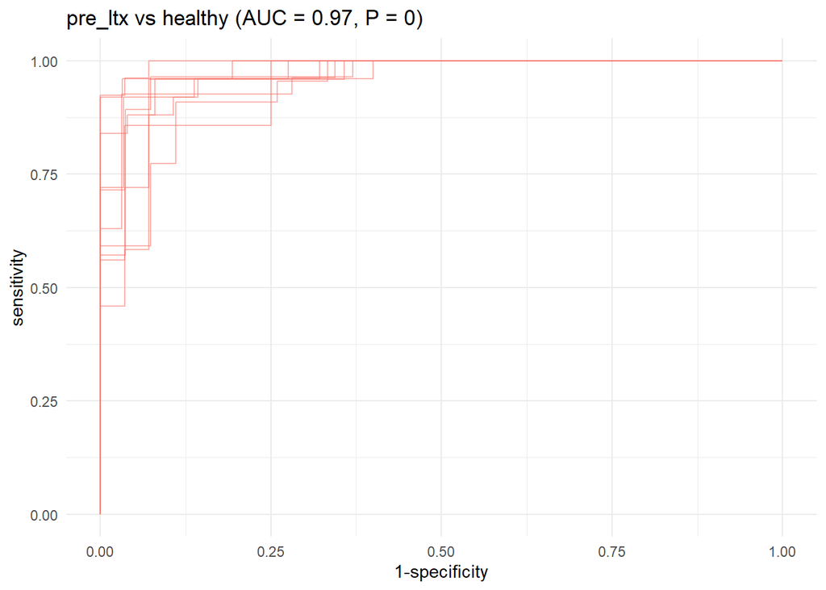

```r
roc_c
```

**pre_ltx vs post_ltx**

```r
group <- c("pre_ltx","post_ltx")
comparison_name <- paste0(group[1], " vs ",group[2])
```

```r
model_name <- paste(comparison_name,level,segment)

# prepare the data
filt_ileum_uni_data <- binomial_prep(ileum_asv_tab,
                                     ileum_taxa_tab,
                                     ileum_metadata,
                                     group, usage="ml_ra")
```

```
Removing 979 ASV(s)
```

```
Removing 68 ASV(s)
```

```r
# fit the model
gbm_model <- gbm_binomial(filt_ileum_uni_data,
                              sample_method = "atypboot",
                              outcome="Group",
                              N=10,
                              reuse=TRUE,
                              file=model_name,
                              Q="Q1")

# ROC curve
roc_c <- roc_curve(gbm_model, group)

# save the results
supplements_models[["models_summ"]][["gbm_model_ra"]][[model_name]] <- gbm_model$model_summary

supplements_models[["roc_cs"]][["gbm_model_ra"]][[model_name]] <- gbm_model$kfold_rocobjs

# see the results
gbm_model$model_summary %>% t()
```

```
                                       [,1]
n.trees                         200.0000000
interaction.depth                 3.0000000
shrinkage                         0.1000000
n.minobsinnode                   10.0000000
auc                               1.0000000
auc_optimism_corrected            0.8818766
auc_optimism_corrected_CIL        0.8250024
auc_optimism_corrected_CIU        0.9331889
accuracy                          1.0000000
accuracy_optimism_corrected       0.8505813
accuracy_optimism_corrected_CIL   0.7753125
accuracy_optimism_corrected_CIU   0.9131829
```

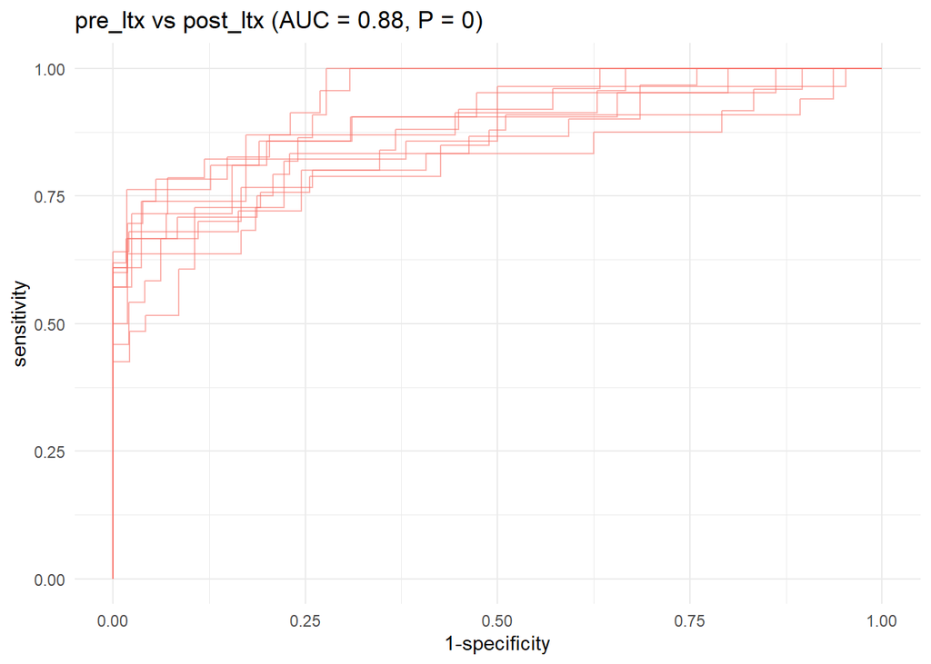

```r
roc_c
```

**post_ltx vs healthy**

```r
group <- c("post_ltx","healthy")
comparison_name <- paste0(group[1], " vs ",group[2])
```

```r
model_name <- paste(comparison_name,level,segment)

# prepare the data
filt_ileum_uni_data <- binomial_prep(ileum_asv_tab,
                                     ileum_taxa_tab,
                                     ileum_metadata,
                                     group, usage="ml_ra")
```

```
Removing 641 ASV(s)
```

```
Removing 104 ASV(s)
```

```r
# fit the model
gbm_model <- gbm_binomial(filt_ileum_uni_data,
                              sample_method = "atypboot",
                              outcome="Group",
                              N=10,
                              reuse=TRUE,
                              file=model_name,
                              Q="Q1")

# ROC curve
roc_c <- roc_curve(gbm_model, group)

# save the results
supplements_models[["models_summ"]][["gbm_model_ra"]][[model_name]] <- gbm_model$model_summary

supplements_models[["roc_cs"]][["gbm_model_ra"]][[model_name]] <- gbm_model$kfold_rocobjs

# see the results
gbm_model$model_summary %>% t()
```

```
                                       [,1]
n.trees                         100.0000000
interaction.depth                 3.0000000
shrinkage                         0.1000000
n.minobsinnode                   10.0000000
auc                               1.0000000
auc_optimism_corrected            0.9152636
auc_optimism_corrected_CIL        0.8490806
auc_optimism_corrected_CIU        0.9591980
accuracy                          1.0000000
accuracy_optimism_corrected       0.8440457
accuracy_optimism_corrected_CIL   0.7779221
accuracy_optimism_corrected_CIU   0.9026667
```

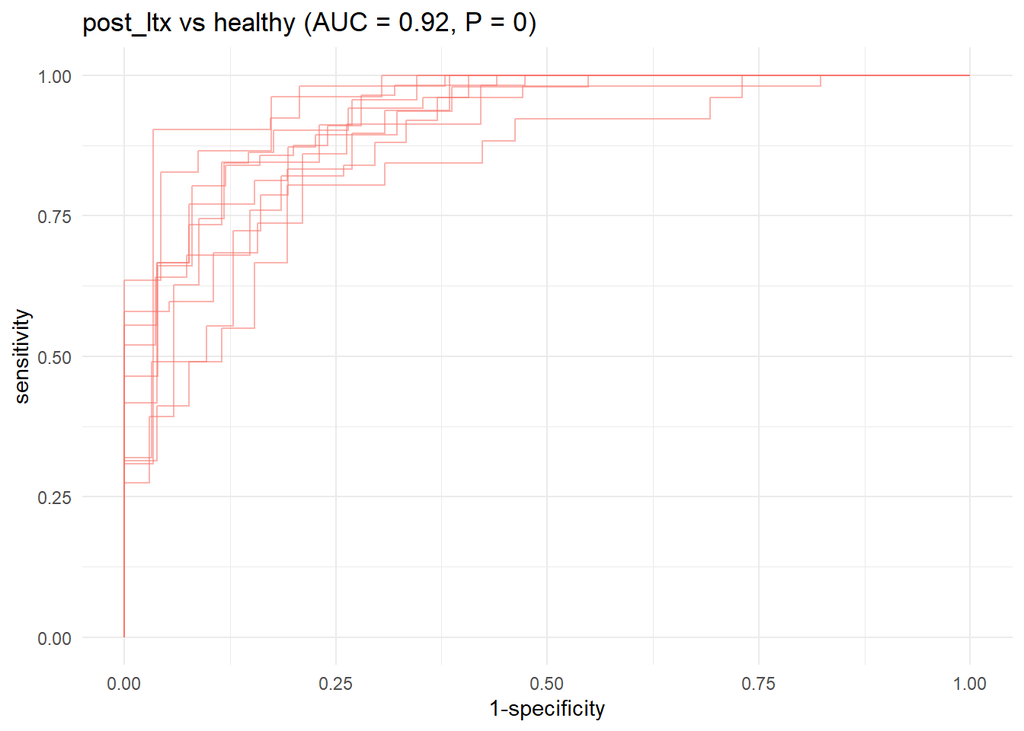

```r
roc_c
```